# GUV_Analysis_summary

James Foster

2025-12-18

## Details

> **AUTHOR**

> James Foster $2025~06~05$

> **MODIFIED**

> James Foster $2025~12~18$

> **DESCRIPTION**

> Loads the reorganised data from `colour_dance_reorg.csv`, saved from `GUV_organisedata.R`, and generates plots to show the how dances changed as a function of light stimulus.

> **INPUTS**

> `colour_dance_reorg.csv`, `Edrich1979_brightness-accuracy.csv`

> **OUTPUTS**

> Plotted results.

> **CHANGES**

> **REFERENCES**

> Edrich, W., Neumeyer, C. and von Helversen, O. (1979). “Anti-sun orientation” of bees with regard to a field of ultraviolet light. *J. Comp. Physiol.* 134, 151–157.

> Rossel, S. and Wehner, R. (1984). Celestial orientation in bees: the use of spectral cues. *J. Comp. Physiol. A* 155, 605–613.

> **TODO**
> - move necessary functions to GUV_functions
> - move raw data to end
> - make functions for result extraction from BRMS
> - neaten up priors for BRMS models

## Setting up

First load the functions and packages required for this project. These can all be found in `GUV_functions.R`, within the same Github repository.

```r
source('GUV_functions.R')
```

Then load the data that will be used. This includes our own dance data, reorganised by `GUV_organisedata.R` as `colour_dance_reorg.csv`, as well as data from Edrich *et al.* (1979) on the relationship between accuracy (mean vector length), wavelength and intensity. This was manually extracted from Fig. 2 and saved in `"Edrich1979_brightness-accuracy.csv`.

```r
#Dance angle data
cd = read.table(file = '1Data/colour_dance_reorg.csv',
                header = T,
                sep  = ',')
#Accuracy data
ed = read.table(file = '1Data/Edrich1979_brightness-accuracy.csv',
                header = T,
                sep  = ',')
#Inspect each dataset
print(cd)
```

```
##      measured_angle run       date bearing       angle                 ID
## 1               270   1 2016.05.31      90  1.57079633   2016.05.31.14.24
## 2                 5   2 2016.05.31     355 -0.08726646   2016.05.31.14.24
## 3                20   3 2016.05.31     340 -0.34906585   2016.05.31.14.24
## 4               320   4 2016.05.31      40  0.69813170   2016.05.31.14.24
## 5                20   5 2016.05.31     340 -0.34906585   2016.05.31.14.24
## 6                35   6 2016.05.31     325 -0.61086524   2016.05.31.14.24
## 7                10   7 2016.05.31     350 -0.17453293   2016.05.31.14.24
## 8               345   8 2016.05.31      15  0.26179939   2016.05.31.14.24
## 9               340   9 2016.05.31      20  0.34906585   2016.05.31.14.24
## 10              340  10 2016.05.31      20  0.34906585   2016.05.31.14.24
## 11              340  11 2016.05.31      20  0.34906585   2016.05.31.14.24
## 12              330  12 2016.05.31      30  0.52359878   2016.05.31.14.24
## 13              350  13 2016.05.31      10  0.17453293   2016.05.31.14.24
## 14              325  14 2016.05.31      35  0.61086524   2016.05.31.14.24
```

[output cut: 12449 more lines]

```r
print(ed)
```

```
##         xx intensity     nn accuracy wavelength
## 1  -31.208  2.15e+09 13.010     0.14        354
## 2  -20.263  3.69e+09 14.249     0.15        535
## 3   -8.217  6.67e+09 19.135     0.20        354
## 4   -1.342  9.36e+09 15.350     0.16        535
## 5   15.118  2.10e+10 30.769     0.33        354
## 6   24.548  3.35e+10 14.731     0.16        535
## 7   32.671  4.99e+10 70.349     0.74        354
## 8   45.199  9.25e+10 37.928     0.40        535
## 9   42.996  8.30e+10 10.463     0.11        429
## 10  61.994  2.12e+11 75.030     0.79        354
## 11  69.360  3.04e+11 70.349     0.74        535
## 12  71.254  3.34e+11 48.460     0.51        429
## 13  96.412  1.15e+12 85.355     0.90        535
## 14  95.448  1.10e+12 72.208     0.76        429
## 15 104.741  1.74e+12 78.059     0.83        354
## 16 118.026  3.34e+12 80.468     0.85        429
## 17 120.986  3.86e+12 89.657     0.95        535
## 18 141.233  1.05e+13 90.189     0.95        535
## 19 141.352  1.05e+13 83.978     0.89        429
## 20 165.252  3.41e+13 91.722     0.97        535
```

## Format data

Ensure that each variable has the correct data format for subsequent analysis.

```r
cd = within(cd,
            {
              ID = as.factor(ID) # beedance identifier as a factor
              date = as.factor(date) # date as a factor
              signed_angle = Mod360.180(bearing)  # bearing between -180 and 180
              angle = circular(rad(signed_angle),# bearing between -pi and pi
                               rotation = 'clock') # circular format suppresses later warnings
            }
)
u_id = with(cd, unique(ID)) # unique beedances
length(u_id)#169 beedances
```

```
## [1] 169
```

Identify dances in which all four stimulus conditions were used.

```r
luc = sapply(u_id,
              FUN = IndCond,
              dt = cd)

#Most individuals that made it to bright green
full_ids = u_id[luc == 4]
length(full_ids)#19 individuals
```

```
## [1] 19
```

```r
#extract just those individuals

#find data for full condition individuals
full_cd = subset(cd, ID %in% full_ids)
```

## Check dance length

```r
mruns = aggregate(run ~ ID,
                  data = cd,
                  FUN = max)
summary(mruns$run)
```

```
##    Min. 1st Qu.  Median    Mean 3rd Qu.    Max.
##   14.00   26.00   33.00   36.83   43.00  100.00
```

## Plot the raw dance data

### Plot an example individual to show effect

For example we can look at the dance recorded on 2016.06.20 at 13:17.

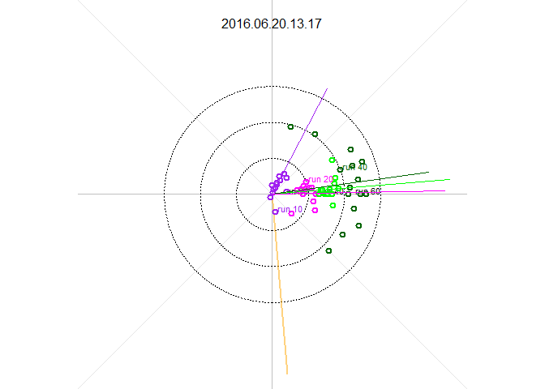

```r
ii = '2016.06.20.13.17'
#set up a sequence for the axes
xc = seq(from = -pi, to = pi-1e-16, length.out = 1e3)
par(pty = 's')
par(mfrow = c(1,1), mar = c(0,0,0,0))
mnv_gh = Mvec(subset(cd, ID %in% ii & colour %in% 'g' & brightn %in% 'h')$angle)
mnv_gl = Mvec(subset(cd, ID %in% ii & colour %in% 'g' & brightn %in% 'l')$angle)
mnv_uh = Mvec(subset(cd, ID %in% ii & colour %in% 'u' & brightn %in% 'h')$angle)
mnv_ul = Mvec(subset(cd, ID %in% ii & colour %in% 'u' & brightn %in% 'l')$angle)
plot(x = NULL,
     xlim = 100*c(-1,1),
     ylim = 100*c(-1,1),
     pch = 19,
     axes = FALSE,
     xlab = '',
     ylab = '',
     main = ''
     )
abline(a = 0, b = 1, col = 'gray90')
abline(a = 0, b = -1, col = 'gray90')
abline(h = 0, v = 0, col = 'gray75')
lines(x = 20*sin(xc), y = 20*cos(xc), lty = 3)
lines(x = 40*sin(xc), y = 40*cos(xc), lty = 3)
lines(x = 60*sin(xc), y = 60*cos(xc), lty = 3)
text(x = 1:3*20,
     y = c(0,0,0),
     labels = paste(' run', 1:3*20),
     cex = 0.7,
     adj = c(1,0))
with(subset(cd, ID %in% ii),
     {
lines(x = c(0, 100*sin(sun_az_rad)),
      y = c(0, 100*cos(sun_az_rad)),
      col = adjustcolor('orange',alpha.f = 0.5),
      lwd = 2)
points(x = run*sin(as.numeric(angle)),
       y = run*cos(as.numeric(angle)),
       bg = gray(level = 1.0,
                 alpha =  0.4),
       col = c('green', 'darkgreen', 'magenta', 'purple')
              [ifelse(colour %in% 'g',
                      yes = ifelse(brightn %in% 'h', yes = 1, no = 2),
                      no = ifelse(brightn %in% 'h', yes = 3, no = 4))],
      pch = 21,
      lwd = 2
     )
     }
)
with(subset(cd, ID %in% ii & run %in% c(10, 20, 40)),
     {
text(x = run*sin(as.numeric(angle)),
     y = run*cos(as.numeric(angle)),
     labels = paste(' run', run),
     col = c('green', 'darkgreen', 'magenta', 'purple')
            [ifelse(colour %in% 'g',
                    yes = ifelse(brightn %in% 'h', yes = 1, no = 2),
                    no = ifelse(brightn %in% 'h', yes = 3, no = 4))],
     cex = 0.7,
     adj = c(0,0))
     }
)

lines(x = c(0,100*sin(mnv_gh['mu'])*mnv_gh['rho']),
      y = c(0,100*cos(mnv_gh['mu'])*mnv_gh['rho']),
      col = 'green',
      lwd = 1)
lines(x = c(0,100*sin(mnv_gl['mu'])*mnv_gl['rho']),
      y = c(0,100*cos(mnv_gl['mu'])*mnv_gl['rho']),
      col = 'darkgreen',
      lwd = 1)
lines(x = c(0,100*sin(mnv_uh['mu'])*mnv_uh['rho']),
      y = c(0,100*cos(mnv_uh['mu'])*mnv_uh['rho']),
      col = 'magenta',
      lwd = 1)
lines(x = c(0,100*sin(mnv_ul['mu'])*mnv_ul['rho']),
      y = c(0,100*cos(mnv_ul['mu'])*mnv_ul['rho']),
      col = 'purple',
      lwd = 1)
mtext(ii,side = 3,line = -2)
```

### Plot all

Plot all 169 dances

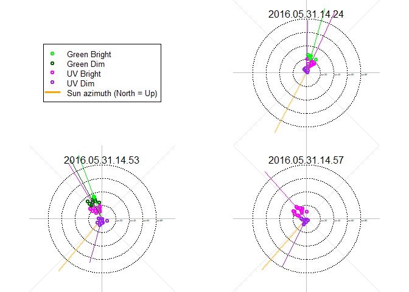

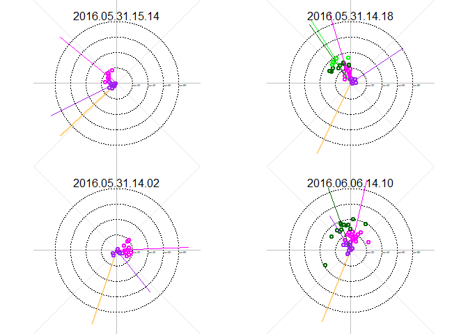

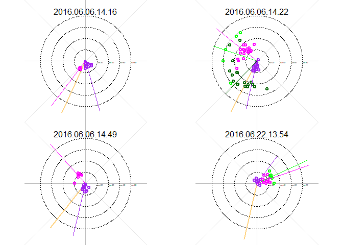

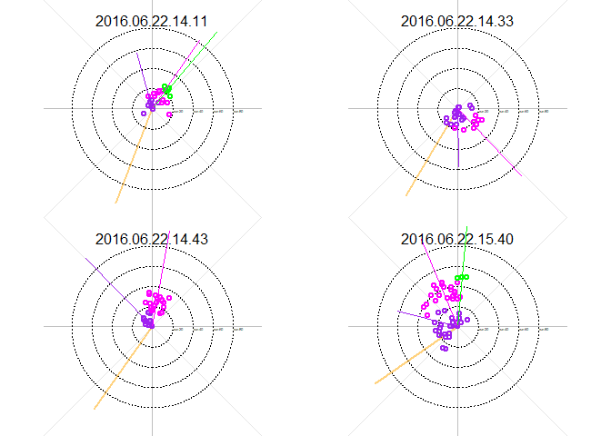

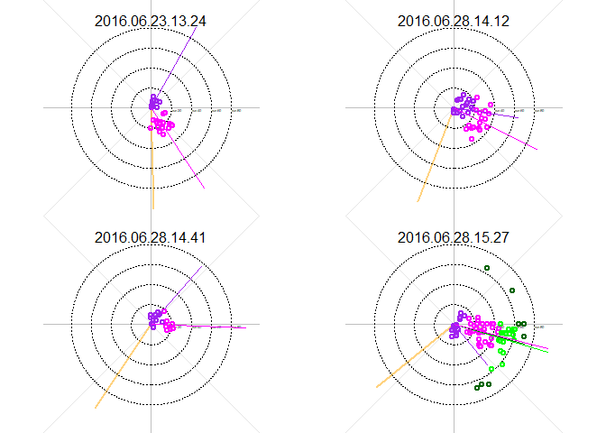

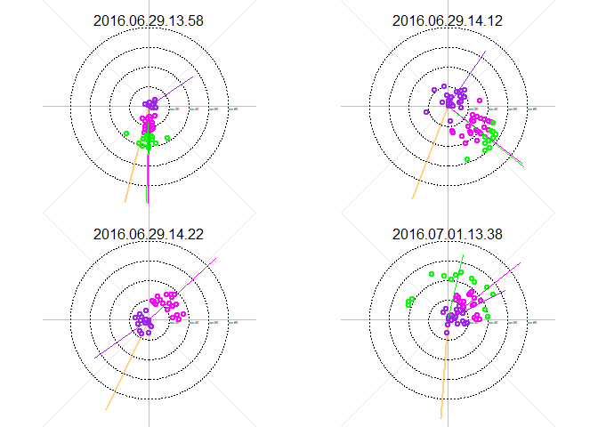

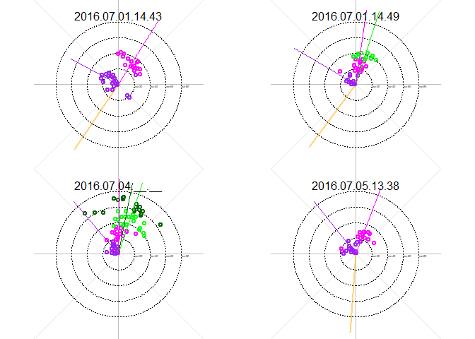

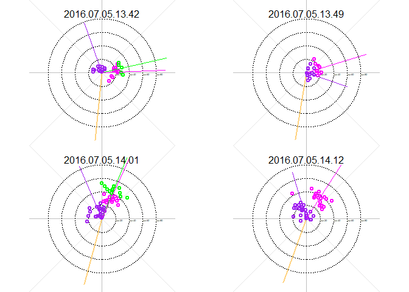

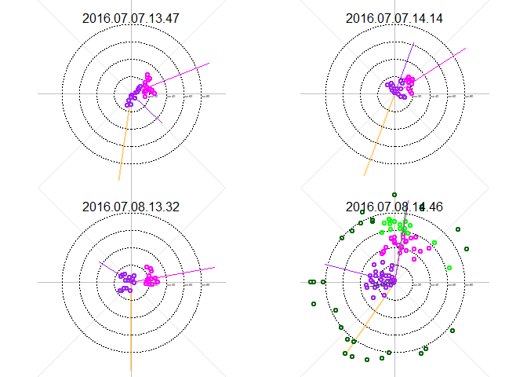

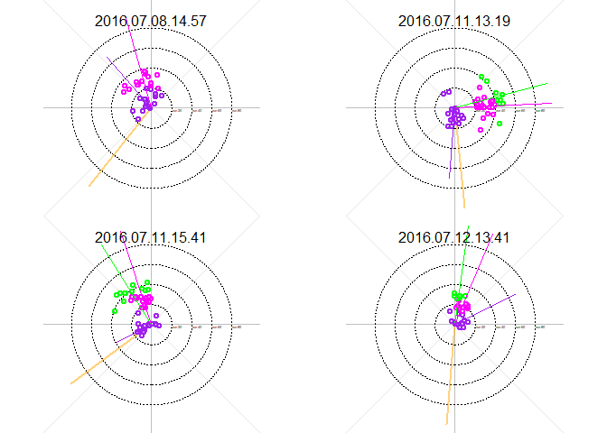

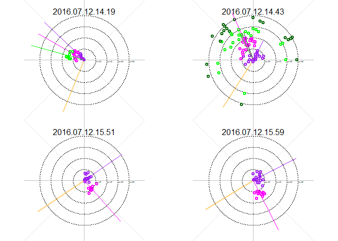

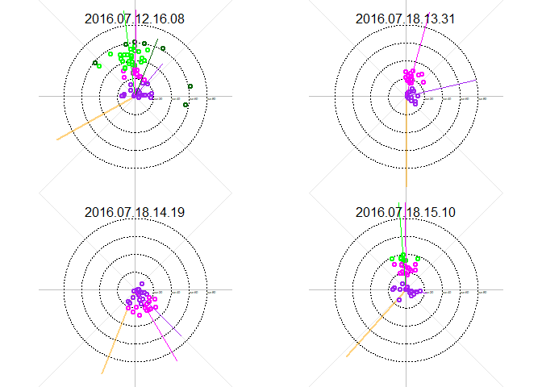

[31 more figures not shown]

## Accuracy effects

Calculate the mean vectors for each set of waggle-runs under each lighting condition.

```
## [1] 88.55
```

```
## [1] 88.24
```

```
## [1] 94.23
```

```
## [1] 88.24
```

### Effect of brightness on mean vector length

#### Entire dataset

The first thing we notice is that in the low intensity conditions the accuracy is generally lower than for the high intensity conditions.

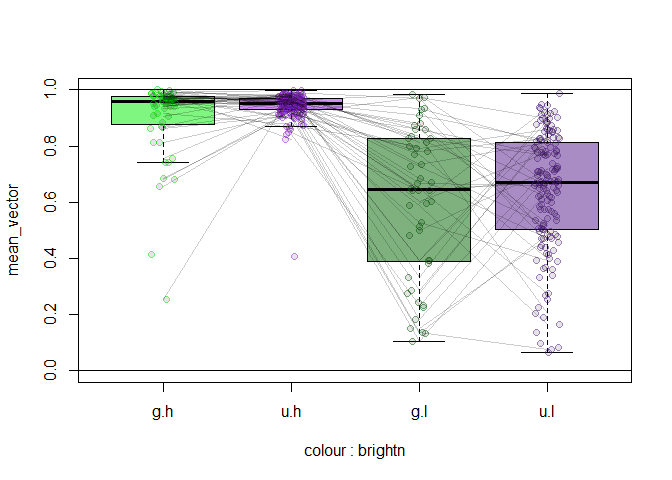

```r
boxplot(mean_vector~colour*brightn,
        data = mean_vectors,
        ylim = c(0,1),
        col = adjustcolor(c('green2',
                            'purple',
                            'darkgreen',
                            'purple4'), alpha.f = 0.5),
        outline = FALSE)
stripchart(mean_vector~colour*brightn,
           data = mean_vectors,
           add = TRUE,
           vertical = TRUE,
           method = 'jitter',
           col = adjustcolor(c('green2',
                               'purple',
                               'darkgreen',
                               'purple4'), alpha.f = 0.5),
           bg = gray(level = 0,
                     alpha = 0.1),
           pch = 21)
#Identify stimuli
stim = apply(X = expand.grid(c = c('g','u'),b = c('h','l')),
             FUN = paste,
             collapse = '',
             MARGIN = 1)
#Plot lines linking dances by the same individual
invisible(
  {
    lapply(X = u_id,
           FUN = Plt_mvec
           )
  })
abline(h = c(0,1))
```

Print summary statistics

```r
mv_agg =  aggregate(mean_vector~colour*brightn,
           data = mean_vectors,
           FUN = quantile,
           probs = c(0.5, 0.25, 0.75))
rownames(mv_agg) = stim
mv_agg = within(mv_agg, rm(colour, brightn))
mv_agg = t(apply(mv_agg, MARGIN = 1, unlist))
print(mv_agg,
  digits = 3)
```

```
##    mean_vector.50% mean_vector.25% mean_vector.75%
## gh           0.958           0.881           0.976
## uh           0.952           0.930           0.969
## gl           0.646           0.391           0.827
## ul           0.671           0.503           0.810
```

#### Within individuals (balanced cases only)

This effect is even clearer if we look at just the full condition dances.

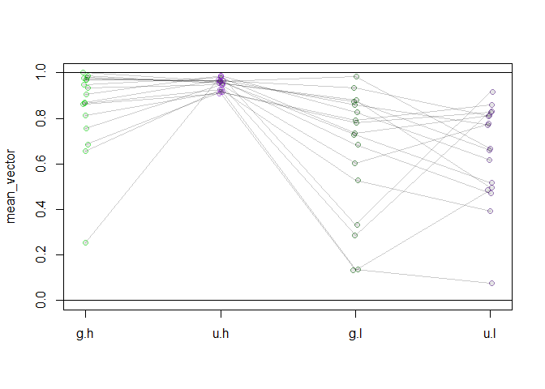

```r
stripchart(mean_vector~colour*brightn,
           data = mean_vectors_full,
           # add = TRUE,
           vertical = TRUE,
           method = 'jitter',
           jitter = 0.02,
           ylim = c(0,1),
           col = adjustcolor(c('green2',
                               'purple',
                               'darkgreen',
                               'purple4'), alpha.f = 0.5),
           bg = gray(level = 0,
                     alpha = 0.1),
           pch = 21)
#Plot lines linking dances by the same individual
invisible(
  {
    lapply(X = full_ids,
           FUN = Plt_mvec
           )
  })
abline(h = c(0,1))
```

### Plot an example individual to show effect

For example we can look at the dance recorded on 2016.06.20 at 13:17.

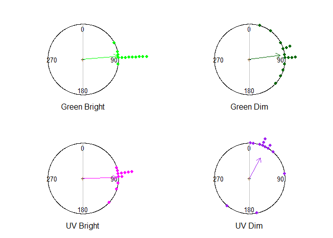

```r
example_subs = subset(x = cd,
                      ID %in% '2016.06.20.13.17')
par(mfrow = c(2,2), mar = c(0,0,0,0))
PCfun(angles = subset(example_subs,
                      subset = colour %in% 'g' & brightn %in% 'h')$bearing,
      col = 'green',
      shrink = 1.5,
      title = 'Green Bright')
PCfun(angles = subset(example_subs,
                      subset = colour %in% 'g' & brightn %in% 'l')$bearing,
      col = 'darkgreen',
      shrink = 1.5,
      title = 'Green Dim')
PCfun(angles = subset(example_subs,
                      subset = colour %in% 'u' & brightn %in% 'h')$bearing,
      col = 'magenta',
      shrink = 1.5,
      title = 'UV Bright')
PCfun(angles = subset(example_subs,
                      subset = colour %in% 'u' & brightn %in% 'l')$bearing,
      col = 'purple',
      shrink = 1.5,
      title = 'UV Dim')
```

### Non-parametric tests on accuracy

Here non-parametric or parametric statistics could be revealing.

```r
#Identify all effects as factors for aligned ranks transform
mean_vectors_full = within(mean_vectors_full,
                           {
                           colour = as.factor(colour)
                           brightn = as.factor(brightn)
                           ID = as.factor(ID)
                           }
                           )
mean_vectors = within(mean_vectors,
                           {
                           colour = as.factor(colour)
                           brightn = as.factor(brightn)
                           ID = as.factor(ID)
                           }
                           )
mv_full_art = art(formula = mean_vector~colour*brightn +
                              (1+colour+brightn|ID),#insufficient DF to estimate interaction
                   data = mean_vectors_full)
sm_mv_full_art = summary(mv_full_art)
```

```
## boundary (singular) fit: see help('isSingular')
## boundary (singular) fit: see help('isSingular')
## boundary (singular) fit: see help('isSingular')
```

```r
#check if rank alignment was successful
message('\nSuccessful rank alignment:\n',
        all(sapply(sm_mv_full_art[11], round) == 0),
        '\n')
```

```
##
## Successful rank alignment:
## TRUE
```

```r
print(anova(mv_full_art), digits = 3)
```

```
## boundary (singular) fit: see help('isSingular')
## boundary (singular) fit: see help('isSingular')
```

```
## Analysis of Variance of Aligned Rank Transformed Data
##
## Table Type: Analysis of Deviance Table (Type III Wald F tests with Kenward-Roger df)
## Model: Mixed Effects (lmer)
## Response: art(mean_vector)
##
##                         F Df Df.res     Pr(>F)
## 1 colour          0.00452  1     16    0.94724
## 2 brightn        56.97631  1     16 1.1689e-06 ***
## 3 colour:brightn  2.99074  1     16    0.10298
## ---
## Signif. codes:   0 '***' 0.001 '**' 0.01 '*' 0.05 '.' 0.1 ' ' 1
```

We can successfully fit an aligned ranks model to compare across individuals. Note that the “boundary” level random effects indicate that individual effects were too small to estimate. In the individual linear models (e.g. `summary(artlm(mv_full_art, "brightn"))$varcor`) there may still be substantial individual differences. The primary effect appears to be that of brightness, but there may also be effects of interest in the post-hoc contrasts.

```r
cn_mv_full_art = sapply(X = c('brightn', 'colour', 'colour:brightn'),
                        FUN = ART_extract,
                        mod = mv_full_art,
                        adjust = 'sidak')
```

```
## NOTE: Results may be misleading due to involvement in interactions
```

```
## boundary (singular) fit: see help('isSingular')
```

```
## NOTE: Results may be misleading due to involvement in interactions
```

```r
print(cn_mv_full_art)
```

```
## $brightn
##  contrast estimate   SE df t.ratio p.value
##  h - l        25.5 3.37 16   7.548  <.0001
##
## Results are averaged over the levels of: colour
## Degrees-of-freedom method: kenward-roger
##
## $colour
##  contrast estimate   SE df t.ratio p.value
##  g - u      -0.353 5.25 16  -0.067  0.9472
##
## Results are averaged over the levels of: brightn
## Degrees-of-freedom method: kenward-roger
##
## $`colour:brightn`
##  contrast  estimate   SE   df t.ratio p.value
##  g,h - g,l    17.71 3.51 28.3   5.038  0.0001
##  g,h - u,h   -11.35 4.84 22.2  -2.347  0.1579
##  g,h - u,l    22.00 6.29 16.0   3.497  0.0178
##  g,l - u,h   -29.06 4.02 16.0  -7.231  <.0001
##  g,l - u,l     4.29 4.84 22.2   0.888  0.9455
##  u,h - u,l    33.35 3.51 28.3   9.490  <.0001
##
## Degrees-of-freedom method: kenward-roger
## P value adjustment: sidak method for 6 tests
```

### Beta model for accuracy

```r
#TODO remove unnecessary priors
### Maximal formula with all random effects ---------------------
#set up model formula with indiv effects on light type
frm_bmod_maxRE = bf(mean_vector~brightn*colour + # light types affect accuracy
                            (1 + brightn*colour|ID), # each individual is more or less oriented
              phi ~ brightn*colour + # light types affect variance in accuracy
                      (1 + brightn*colour|ID), # some individuals vary more in accuracy than others
              family = brms::Beta())

#suggest prior values
pr_mu_Intercept = list(dist = 'normal',
             mu = 0,
             sd = 1)#deconstrain to beat divergences?
pr_phi_Intercept = list(dist = 'normal',
             mu = 1,
             sd = 1)
pr_mu_b = list(dist = 'normal',
             mu = 0,
             sd = 1)#deconstrain to beat divergences?
pr_phi_b = list(dist = 'normal',
             mu = 0,
             sd = 1)
pr_mu_sd_Intercept = list(dist = 'student_t',
             df = 3,
             mu = 0,
             sd = 0.1)#constrain to beat divergences?
pr_phi_sd_Intercept = list(dist = 'student_t',
                 df = 3,
                 mu = 0,
                 sd = 0.1)#constrain to beat divergences?
pr_mu_sd = list(dist = 'student_t',
             df = 3,
             mu = 0,
             sd = 0.1)#constrain to beat divergences?
pr_phi_sd = list(dist = 'student_t',
                 df = 3,
                 mu = 0,
                 sd = 0.1)#constrain to beat divergences?

### Assign priors --------------------------------------------------------

#set priors on:
# - all coefficients to a normal(0,1) = 95% probability of values 0.12–0.87
# - all grouping paramters to a student_t(df = 3, mu = 0, sigma = 2.5) = values < 5.88
# - all other parameters (?) to a normal(0,10)= 95% probability of values 0–1 +- 1e-7

pr_expression = expression({
  prior = sapply(class,
                 switch,
                 Intercept = with(pr_mu_Intercept,
                          {paste0(dist,'(',mu,',',sd,')')}),
                 #the general prior for coefficients (should centre on 0)
                 b = with(pr_mu_b,
                          {paste0(dist,'(',mu,',',sd,')')}),
                 #the general prior for standard deviations (should be long-tailed)
                 sd =  with(pr_mu_sd,
                           {paste0(dist,'(',df,',',mu,',',sd,')')}),
                 cor = 'lkj(1)', # The only supported prior for correlation matrices is the 'lkj' prior
                 'normal(0,1)' # with this many params need more informative priors
      )
  #special priors
    #mu sd intercept
  prior[dpar %in% '' & class %in% 'sd' & coef %in% ''] =
    with(pr_mu_sd_Intercept,
                          {paste0(dist,'(',df,',',mu,',',sd,')')})
  #phi b
  prior[dpar %in% 'phi' & class %in% 'b'] =
    with(pr_phi_b,
                          {paste0(dist,'(',mu,',',sd,')')})
  #phi intercept
  prior[dpar %in% 'phi' & class %in% 'b' & coef %in% ''] =
    with(pr_phi_Intercept,
                          {paste0(dist,'(',mu,',',sd,')')})
  #phi sd
  prior[dpar %in% 'phi' & class %in% 'sd'] =
    with(pr_phi_sd,
                          {paste0(dist,'(',df,',',mu,',',sd,')')})
  #phi sd intercept
  prior[dpar %in% 'phi' & class %in% 'sd' & coef %in% ''] =
    with(pr_phi_sd_Intercept,
                          {paste0(dist,'(',df,',',mu,',',sd,')')})
}
)

#model with all random effects
priors_bmod_mxRE = within(get_prior(formula = frm_bmod_maxRE,
                                    data = mean_vectors_full),
                          expr = eval(pr_expression))
print(priors_bmod_mxRE)#all parameters are accounted for
```

```
##               prior     class             coef group resp dpar nlpar lb ub tag
##         normal(0,1)         b
##         normal(0,1)         b         brightnl
##         normal(0,1)         b brightnl:colouru
##         normal(0,1)         b          colouru
##              lkj(1)       cor
##              lkj(1)       cor                     ID
##         normal(0,1) Intercept
##  student_t(3,0,0.1)        sd                                         0
##  student_t(3,0,0.1)        sd                     ID                  0
##  student_t(3,0,0.1)        sd         brightnl    ID                  0
##  student_t(3,0,0.1)        sd brightnl:colouru    ID                  0
##  student_t(3,0,0.1)        sd          colouru    ID                  0
##  student_t(3,0,0.1)        sd        Intercept    ID                  0
##         normal(1,1)         b                              phi
##         normal(0,1)         b         brightnl             phi
##         normal(0,1)         b brightnl:colouru             phi
##         normal(0,1)         b          colouru             phi
##         normal(0,1) Intercept                              phi
##  student_t(3,0,0.1)        sd                              phi        0
##  student_t(3,0,0.1)        sd                     ID       phi        0
##  student_t(3,0,0.1)        sd         brightnl    ID       phi        0
##  student_t(3,0,0.1)        sd brightnl:colouru    ID       phi        0
##  student_t(3,0,0.1)        sd          colouru    ID       phi        0
##  student_t(3,0,0.1)        sd        Intercept    ID       phi        0
##   source
##  default
##  default
##  default
##  default
##  default
##  default
##  default
##  default
##  default
##  default
##  default
##  default
##  default
##  default
##  default
##  default
##  default
##  default
##  default
##  default
##  default
##  default
##  default
##  default
```

```
##    user  system elapsed
##    5.14    0.77  178.52
```

```
##    Min. 1st Qu.  Median    Mean 3rd Qu.    Max.
##  0.9993  1.0002  1.0006  1.0007  1.0012  1.0037
```

```
##                      Estimate l-95% CI u-95% CI
## Intercept               1.794    1.296    2.283
## phi_Intercept           1.596    0.976    2.161
## brightnl               -1.215   -1.876   -0.551
## colouru                 0.994    0.400    1.561
## brightnl:colouru       -0.966   -1.728   -0.189
## phi_brightnl           -0.661   -1.452    0.139
## phi_colouru             1.886    0.849    2.833
## phi_brightnl:colouru   -1.084   -2.243    0.166
```

Extract the model’s predictions and compare with the original data.

```
## Ignoring unknown labels:
## • fill : "NA"
## • colour : "NA"
## Ignoring unknown labels:
## • fill : "NA"
## • colour : "NA"
```

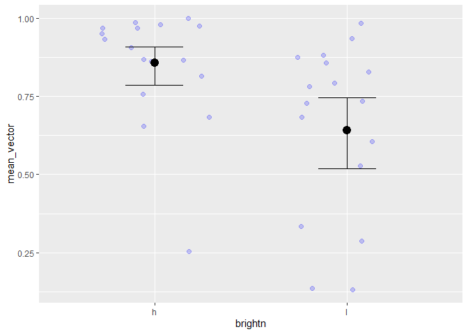

```
## Ignoring unknown labels:
## • fill : "NA"
## • colour : "NA"
## Ignoring unknown labels:
## • fill : "NA"
## • colour : "NA"
```

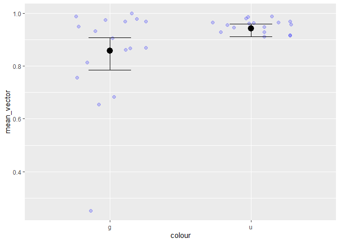

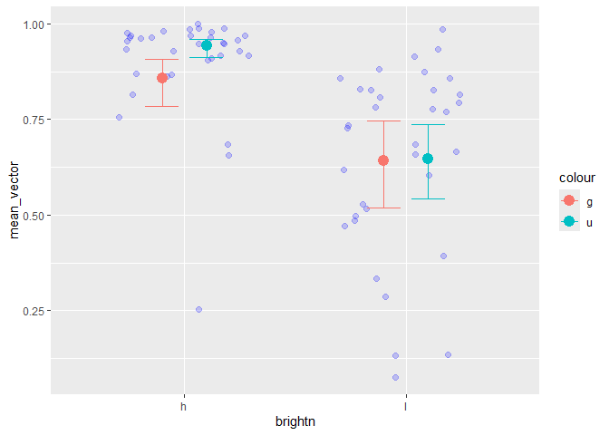

This seems to suggest that dances were more accurate in the bright UV condition, which the aligned-ranks test was sceptical of. We can quantify this difference by extracting and comparing the parameter estimates from each (post-warmup) iteration of the model.

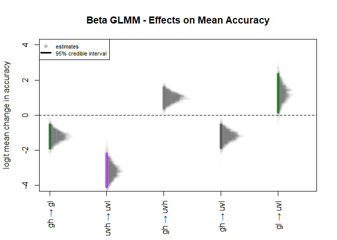

```r
draws_beta = prepare_predictions(md_beta,
                                 re_formula = NA)#just population level effects
#for the average vector length
draws_mu = draws_beta$dpars$mu$fe$b
#for variance in vector length
draws_phi = draws_beta$dpars$phi$fe$b
#N.B. Could also just calculate predictions, then subtract
contr_mu = with(data.frame(draws_mu),
                {
                  data.frame(
                    #bright green -> dim green = low brightness effect
                    gh_gl = b_brightnl,
                    #bright UV -> dim UV = dim + UVdim - UV effect
                    uvh_uvl = b_brightnl + `b_brightnl.colouru` - b_colouru,
                    #bright green -> bright UV = UV effect
                    gh_uvh = b_colouru,
                    #bright green -> dim UV = UV + dim + UVdim
                    gh_uvl = b_brightnl + b_colouru + `b_brightnl.colouru`,
                    #dim green -> dim UV = UV effect + UVdim - dim effect
                    gl_uvl = b_colouru + `b_brightnl.colouru` - b_brightnl
                  )
                }
                )
#On the original scale
contr_rho = with(data.frame(draws_mu),
                {
                  data.frame(
                    #bright green -> dim green = low brightness effect
                    gh_gl = plogis(b_Intercept + b_brightnl) -
                              plogis(b_Intercept),
                    #bright UV -> dim UV = dim + UVdim - UV effect
                    uvh_uvl = plogis(b_Intercept + b_brightnl + `b_brightnl.colouru`) -
                              plogis(b_Intercept + b_colouru),
                    #bright green -> bright UV = UV effect
                    gh_uvh = plogis(b_Intercept + b_colouru) -
                              plogis(b_Intercept),
                    #bright green -> dim UV = UV + dim + UVdim
                    gh_uvl = plogis(b_Intercept + b_brightnl +
                                      b_colouru + `b_brightnl.colouru`)-
                              plogis(b_Intercept),
                    #dim green -> dim UV = UV effect + UVdim - dim effect
                    gl_uvl = plogis(b_Intercept + b_colouru +
                                      `b_brightnl.colouru`) -
                              plogis(b_Intercept + b_brightnl)
                  )
                }
                )

contr_phi = with(data.frame(draws_phi),
                {
                  data.frame(
                    #bright green -> dim green = low brightness effect
                    gh_gl = b_phi_brightnl,
                    #bright UV -> dim UV = dim + UVdim - UV effect
                    uvh_uvl = b_phi_brightnl + `b_phi_brightnl.colouru` - b_phi_colouru,
                    #bright green -> bright UV = UV effect
                    gh_uvh = b_phi_colouru,
                    #bright green -> dim UV = UV + dim + UVdim
                    gh_uvl = b_phi_brightnl + b_phi_colouru + b_phi_brightnl.colouru,
                    #dim green -> dim UV = UV effect + UVdim - dim effect
                    gl_uvl = b_phi_colouru + `b_phi_brightnl.colouru` - b_phi_brightnl
                  )
                }
                )
contr_all = cbind(contr_mu, contr_phi)
quant_all = apply(X = contr_all,
                  MARGIN = 2,
                  FUN = quantile,
                  probs = c(0,0.5,1)+c(1,0,-1)*(0.05)/2
                  )
quant_mu = apply(X = contr_mu,
                  MARGIN = 2,
                  FUN = quantile,
                  probs = c(0,0.5,1)+c(1,0,-1)*(0.05)/2
                  )
quant_rho = apply(X = contr_rho,
                  MARGIN = 2,
                  FUN = quantile,
                  probs = c(0,0.5,1)+c(1,0,-1)*(0.05)/2
                  )
quant_phi = apply(X = contr_phi,
                  MARGIN = 2,
                  FUN = quantile,
                  probs = c(0,0.5,1)+c(1,0,-1)*(0.05)/2
                  )
stripchart(x = round(contr_mu,2),
           at = 1:dim(contr_mu)[2],
           group.names = gsub(pattern = '_',
                              replacement = ' → ',
                              x = names(contr_mu)),
           main = 'Beta GLMM - Effects on Mean Accuracy',
           ylab = 'logit mean change in accuracy',
           vertical  = TRUE,
           method = 'stack',
           offset =  0.05,
           ylim = c(-1, 1)*4,
           pch = 20,
           col = gray(0, alpha = 4/2e3),
           cex.axis = 1.0,
           las = 3
           )
abline(h = 0,
       lty = 2)
with(data.frame(t(quant_mu)),
     {
      arrows(x0 = 1:dim(quant_mu)[2],
             y0 = X2.5.,
             y1 = X97.5.,
             length = 0,
             angle = 90,
             lwd = 5,
             col = adjustcolor(c('darkgreen',
                            'purple',
                            'gray40',
                            'gray25'
                            ), alpha = 0.7)
             )
     }
)
legend(x = 'topleft',
       legend = c('estimates',
                  '95% credible interval'),
       pch = c(20, NA),
       lty = c(NA, 1),
       lwd = c(5, 3),
       col = c('gray', 'black'),
       cex = 0.7
       )
```

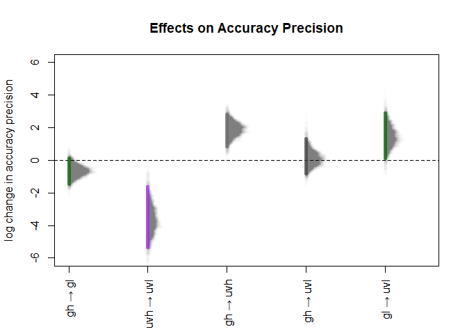

```r
stripchart(x = round(contr_phi,2),
           at = 1:dim(contr_phi)[2],
           group.names = sub(pattern = '_',
                              replacement = ' → ',
                              x = names(contr_phi)),
           main = 'Effects on Accuracy Precision',
           ylab = 'log change in accuracy precision',
           vertical  = TRUE,
           method = 'stack',
           offset =  0.05,
           ylim = c(-1, 1)*6,
           pch = 20,
           col = gray(0, alpha = 4/2e3),
           cex.axis = 1.0,
           las = 3
           )
abline(h = 0,
       lty = 2)
with(data.frame(t(quant_phi)),
     {
      arrows(x0 = 1:dim(quant_phi)[2],
             y0 = X2.5.,
             y1 = X97.5.,
             length = 0,
             angle = 90,
             lwd = 5,
             col = adjustcolor(c('darkgreen',
                            'purple',
                            'gray40',
                            'gray25'
                            ), alpha = 0.7)
             )
     }
)
```

```r
#can also calculate these with emmeans
em_beta = emmeans(object = md_beta,
                  specs = ~brightn*colour)
ct_beta_mu = contrast(object = em_beta,
                   specs = ~brightn*colour,
                   method = 'pairwise',
                   side = c(1,-1,1,-1,-1,1)
                   )
print(ct_beta_mu, digits = 3)
```

```
##  contrast  estimate lower.HPD upper.HPD
##  h g - l g   1.2164     0.605     1.925
##  h g - h u  -1.0019    -1.540    -0.388
##  h g - l u   1.1809     0.557     1.858
##  l g - h u  -2.2126    -2.850    -1.558
##  l g - l u  -0.0291    -0.613     0.585
##  h u - l u   2.1898     1.626     2.755
##
## Point estimate displayed: median
## Results are given on the log odds ratio (not the response) scale.
## HPD interval probability: 0.95
```

```r
#collect and estimate p values from samples
empirical.p = function(x, tails = 2){ifelse(test = median(x)>0,
                                            yes = mean(x<0)*tails,
                                            no = mean(x>0)*tails)
}

p_beta_mu = apply(X = contr_mu, MARGIN = 2, FUN = empirical.p, tails = 2)
p_beta_phi = apply(X = contr_phi, MARGIN = 2, FUN = empirical.p, tails = 2)
beta_all_res = data.frame(rho_lower = quant_rho[1,],
                          rho_median = quant_rho[2,],
                          rho_upper = quant_rho[3,],
                          mu_lower = quant_mu[1,],
                          mu_median = quant_mu[2,],
                          mu_upper = quant_mu[3,],
                          p_mu = p_beta_mu,
                          p_mu_adj = p.adjust(p = p_beta_mu,
                                              method = 'BH'),
                          phi_lower = quant_phi[1,],
                          phi_median = quant_phi[2,],
                          phi_upper = quant_phi[3,],
                          p_phi = p_beta_phi,
                          p_phi_adj = p.adjust(p = p_beta_phi,
                                              method = 'BH')
                          )
print(beta_all_res[,c(2,5,7,10)], digits = 3)
```

```
##         rho_median mu_median   p_mu phi_median
## gh_gl       -0.214     -1.22 0.0000     -0.661
## uvh_uvl     -0.537     -3.19 0.0000     -3.683
## gh_uvh       0.084      1.00 0.0035      1.907
## gh_uvl      -0.208     -1.18 0.0005      0.104
## gl_uvl       0.218      1.23 0.0215      1.430
```

#### Investigate effect of sun elevation

```r
### Maximal formula with all random effects ---------------------
#set up model formula with indiv effects on light type
frm_elemod_maxRE = bf(mean_vector~ cos(sun_el_rad) + # accuracy is affected by projection distortion at high elevations following a cosine law
                            (1 |ID), # each individual is more or less oriented
              phi ~ cos(sun_el_rad) + # accuracy is affected by projection distortion at high elevations following a cosine law
                      (1 |ID), # some individuals vary more in accuracy than others
              family = brms::Beta())

#suggest prior values
pr_mu_Intercept = list(dist = 'normal',
             mu = 0,
             sd = 1)#deconstrain to beat divergences?
pr_phi_Intercept = list(dist = 'normal',
             mu = 1,
             sd = 1)
pr_mu_b = list(dist = 'normal',
             mu = 0,
             sd = 1)#deconstrain to beat divergences?
pr_phi_b = list(dist = 'normal',
             mu = 0,
             sd = 1)
pr_mu_sd_Intercept = list(dist = 'student_t',
             df = 3,
             mu = 0,
             sd = 0.1)#constrain to beat divergences?
pr_phi_sd_Intercept = list(dist = 'student_t',
                 df = 3,
                 mu = 0,
                 sd = 0.1)#constrain to beat divergences?
pr_mu_sd = list(dist = 'student_t',
             df = 3,
             mu = 0,
             sd = 0.1)#constrain to beat divergences?
pr_phi_sd = list(dist = 'student_t',
                 df = 3,
                 mu = 0,
                 sd = 0.1)#constrain to beat divergences?

### Assign priors --------------------------------------------------------

#set priors on:
# - all coefficients to a normal(0,1) = 95% probability of values 0.12–0.87
# - all grouping paramters to a student_t(df = 3, mu = 0, sigma = 2.5) = values < 5.88
# - all other parameters (?) to a normal(0,10)= 95% probability of values 0–1 +- 1e-7

pr_expression = expression({
  prior = sapply(class,
                 switch,
                 Intercept = with(pr_mu_Intercept,
                          {paste0(dist,'(',mu,',',sd,')')}),
                 #the general prior for coefficients (should centre on 0)
                 b = with(pr_mu_b,
                          {paste0(dist,'(',mu,',',sd,')')}),
                 #the general prior for standard deviations (should be long-tailed)
                 sd =  with(pr_mu_sd,
                           {paste0(dist,'(',df,',',mu,',',sd,')')}),
                 cor = 'lkj(1)', # The only supported prior for correlation matrices is the 'lkj' prior
                 'normal(0,1)' # with this many params need more informative priors
      )
  #special priors
    #mu sd intercept
  prior[dpar %in% '' & class %in% 'sd' & coef %in% ''] =
    with(pr_mu_sd_Intercept,
                          {paste0(dist,'(',df,',',mu,',',sd,')')})
  #phi b
  prior[dpar %in% 'phi' & class %in% 'b'] =
    with(pr_phi_b,
                          {paste0(dist,'(',mu,',',sd,')')})
  #phi intercept
  prior[dpar %in% 'phi' & class %in% 'b' & coef %in% ''] =
    with(pr_phi_Intercept,
                          {paste0(dist,'(',mu,',',sd,')')})
  #phi sd
  prior[dpar %in% 'phi' & class %in% 'sd'] =
    with(pr_phi_sd,
                          {paste0(dist,'(',df,',',mu,',',sd,')')})
  #phi sd intercept
  prior[dpar %in% 'phi' & class %in% 'sd' & coef %in% ''] =
    with(pr_phi_sd_Intercept,
                          {paste0(dist,'(',df,',',mu,',',sd,')')})
}
)

#model with all random effects
priors_elemod_mxRE = within(get_prior(formula = frm_elemod_maxRE,
                                    data = mean_vectors_full),
                          expr = eval(pr_expression))
print(priors_elemod_mxRE)#all parameters are accounted for
```

```
##               prior     class          coef group resp dpar nlpar lb ub tag
##         normal(0,1)         b
##         normal(0,1)         b cossun_el_rad
##         normal(0,1) Intercept
##  student_t(3,0,0.1)        sd                                      0
##  student_t(3,0,0.1)        sd                  ID                  0
##  student_t(3,0,0.1)        sd     Intercept    ID                  0
##         normal(1,1)         b                           phi
##         normal(0,1)         b cossun_el_rad             phi
##         normal(0,1) Intercept                           phi
##  student_t(3,0,0.1)        sd                           phi        0
##  student_t(3,0,0.1)        sd                  ID       phi        0
##  student_t(3,0,0.1)        sd     Intercept    ID       phi        0
##   source
##  default
##  default
##  default
##  default
##  default
##  default
##  default
##  default
##  default
##  default
##  default
##  default
```

```
##    user  system elapsed
##    1.74    0.95   62.39
```

```
##    Min. 1st Qu.  Median    Mean 3rd Qu.    Max.
##  0.9994  1.0001  1.0004  1.0006  1.0007  1.0028
```

```
##                   Estimate l-95% CI u-95% CI
## Intercept            1.600   0.6402    2.541
## phi_Intercept        1.175   0.0598    2.295
## cossun_el_rad       -0.767  -2.2238    0.698
## phi_cossun_el_rad   -0.257  -1.9041    1.385
```

Extract the model’s predictions and compare with the original data.

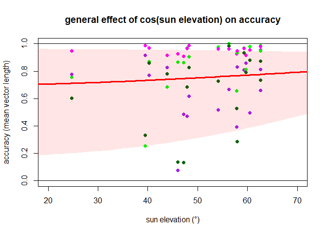

```r
loo_beta = loo(md_beta)
loo_ele = loo(md_ele)
loo_compare(loo_beta, loo_ele)
```

```
##         elpd_diff se_diff
## md_beta   0.0       0.0
## md_ele  -21.7       6.0
```

### Comparison with Edrich *et al.* (1979)

How does this compare with previous experiments in which a light spot (2.3°) was presented through bandpass filters and ND filters to produce different intensities? In that data, there was a clear sigmoidal relationship between intensity and accuracy (mean vector length). They mention that the particular relationship with light intensity was variable, but that the relative relationships remained constant, so we may also observe the same relationship but shifted.

> Unfortunately, the scatter of the dance directions as a function of light intensity proved to be unstable over long periods of time; the absolute values changed from day to day. However, these changes were such that curves for adjacent wavelengths were shifted in parallel - the relative sensitivities remained constant. — Edrich et al. (1979), p154

#### Plot raw data from Edrich *et al.* (1979) Fig. 2

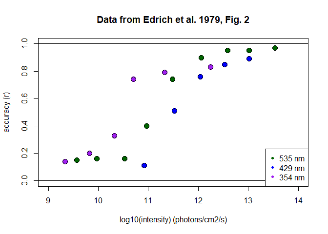

This is best modelled with a nonlinear (psychometric model) following the beta distribution (for variables bounded between zero and one).

#### Reorganise data

```r
ed = within(ed,
            {
              logit_accuracy = qlogis(accuracy)
              log10_intensity = log10(intensity)
              colour = sapply(paste(wavelength),
                              FUN = switch,
                              `354` = 'UV',
                              `429` = 'blue',
                              `535` = '0green',
                              NA)
            }
            )
```

#### Fit psychometric curves

For each light stimulus, fit a sigmoid curve bounded between baseline accuracy (shared across stimuli) and maximum accuracy (`1 - lapses`). Inflection point and 80%-rise-region width vary between stimuli, maximising posterior probability for a beta distribution in `(0,1)`. To do this, we first define a nonlinear formula in `brms`.

```r
#set up model fit
formula_beta = bf(
  formula = accuracy ~
    inv_logit(LogitBase) + (1 - inv_logit(LogitLapse) - inv_logit(LogitBase) ) *#curve region
    inv_logit( 4.39*(log10_intensity - Inflex) / exp(LogWidth) ) , #inflection-width curve
  # for each of these parameters, we can set up a separate formula
  # that describes how to predict them from the data
  #Base rate of correct choices: "
  LogitBase ~ 1, #Base rate of correct choices: "~ 1" gives the instruction "estimate the mean across all data"
  #Lapse rate on a log(odds) scale:
  LogitLapse ~ colour, #this is similar to the formula in our LMM example
  #inflection point of the initial curve:
  Inflex ~ colour, #N.B. this is similar to the intercept, so it does not include effects of stimulus level
  #log 80% width of the curve:
  LogWidth ~ colour, #N.B. this is similar to the slope, so all of its effects depend on stimulus level
  family = Beta(link = "identity", link_phi = 'log'),
  nl = TRUE)#the joint distribution for these parameters is undefined, and therefore the parameters themselves are "nonlinear"
```

Since this is a nonlinear model (there are terms both inside and outside the logistic transform) it is important to establish prior distributions for all parameters. These ensure that parameter estimates explore credible ranges during fitting. The baseline is expected to be around $r = 0.27$, while the maximum accuracy should be around $r = 0.95$, and their estimates should not converge (that would flatten the curve, or reverse its direction). The inflection points are expected around $10^{11}$ photons cm$^{-2}$ s$^{-1}$, with a rise-region width of $10^{3}$ photons cm$^{-2}$ s$^{-1}$. All colour effects may vary by a few orders of magnitude.

```r
#set up priors
prior_beta = get_prior(formula = formula_beta,
                     data = ed)
#set the prior distribution
prior_beta = within(prior_beta,
                  { prior[
                    class %in% 'b' & #just the fixed effects
                      nlpar %in% 'LogitBase' &
                      coef %in% 'Intercept'
                  ] = 'normal(-1,1)' #a normal distribution centred on plogis(-1) = 0.27
                  })
#this prior is automatically bounded between 0 and 1,
#Lapse rate priors ---------------------------------------------------
prior_beta = within(prior_beta,
                  { prior[
                    class %in% 'b' & #just the fixed effects
                      nlpar %in% 'LogitLapse' &
                      coef %in% 'Intercept'
                  ] = 'normal(-3,2)' #a normal distribution centred on -3
                  })

#for all other fixed effects on lapse rate, we'll suggest values around 0 (no effect)
prior_beta = within(prior_beta,
                  { prior[
                    class %in% 'b' & #just the fixed effects
                      nlpar %in% 'LogitLapse' &
                      coef %in% 'colourblue'
                  ] = 'normal(0,2)' #a normal distribution:mean 0, sd 3
                  })
prior_beta = within(prior_beta,
                  { prior[
                    class %in% 'b' & #just the fixed effects
                      nlpar %in% 'LogitLapse' &
                      coef %in% 'colourUV'
                  ] = 'normal(0,2)' #a normal distribution:mean 0, sd 3
                  })

#Inflection point priors ---------------------------------------------
prior_beta = within(prior_beta,
                  { prior[
                    class %in% 'b' & #just the fixed effects
                      nlpar %in% 'Inflex' &
                      coef %in% 'Intercept'
                  ] = 'normal(11,2)' #a normal distribution:mean 11, sd 2
                  })
#for all coefficients, we'll suggest values around 0 (no effect)
prior_beta = within(prior_beta,
                  { prior[
                    class %in% 'b' & #just the fixed effects
                      nlpar %in% 'Inflex' &
                      coef %in% 'colourblue'
                  ] = 'normal(0,2)' #a normal distribution:mean 0, sd 2
                  })

prior_beta = within(prior_beta,
                  { prior[
                    class %in% 'b' & #just the fixed effects
                      nlpar %in% 'Inflex' &
                      coef %in% 'colourUV'
                  ] = 'normal(0,2)' #a normal distribution:mean 0, sd 2
                  })

#Rise region width priors --------------------------------------------
prior_beta = within(prior_beta,
                  { prior[
                    class %in% 'b' & #just the fixed effects
                      nlpar %in% 'LogWidth' &
                      coef %in% 'Intercept'
                  ] = 'normal(1,2)' #a normal distribution:mean 1, sd 3
                  })
#for all coefficients, we'll suggest values around 0 (no effect)
prior_beta = within(prior_beta,
                  { prior[
                    class %in% 'b' & #just the fixed effects
                      nlpar %in% 'LogWidth' &
                      coef %in% 'colourblue'
                  ] = 'normal(0,2)' #a normal distribution:mean 0, sd 3
                  })
prior_beta = within(prior_beta,
                  { prior[
                    class %in% 'b' & #just the fixed effects
                      nlpar %in% 'LogWidth' &
                      coef %in% 'colourUV'
                  ] = 'normal(0,2)' #a normal distribution:mean 0, sd 3
                  })
```

Fit a psychometric model to the data using the nonlinear formula and specified prior distributions. `4000` iterations on `4` chains takes less than one minute.

```r
#takes less than 1 minute
#parameters for the brms runs
wup = 2000
sam = 2000
refr = 0
system.time(
  {
    beta_fit = brm( formula = formula_beta, # using our nonlinear formula
                     data = ed, # our data
                     prior = prior_beta, # our priors
                     iter = wup+sam, # long run for 4000 iterations
                     chains = 4, # 4 chains in parallel
                     cores = 4, # on 4 CPUs
                     refresh = refr,
                     silent = 0, # don't echo chain progress
                     control = list(adapt_delta = 0.95), #finer sampling
                     backend = 'cmdstanr') # use cmdstanr (other compilers broken)
  }
)
```

```
## Running MCMC with 4 parallel chains...
```

```
## Chain 3 Informational Message: The current Metropolis proposal is about to be rejected because of the following issue:
```

```
## Chain 3 Exception: beta_lpdf: Second shape parameter[9] is 0, but must be positive finite! (in 'C:/Users/JAMESF~1/AppData/Local/Temp/RtmpO84xTL/model-38c86c0350d6.stan', line 64, column 4 to column 56)
```

```
## Chain 3 If this warning occurs sporadically, such as for highly constrained variable types like covariance matrices, then the sampler is fine,
```

```
## Chain 3 but if this warning occurs often then your model may be either severely ill-conditioned or misspecified.
```

```
## Chain 3
```

```
## Chain 3 finished in 10.1 seconds.
## Chain 2 finished in 10.3 seconds.
## Chain 1 finished in 10.7 seconds.
## Chain 4 finished in 12.0 seconds.
##
## All 4 chains finished successfully.
## Mean chain execution time: 10.8 seconds.
## Total execution time: 12.3 seconds.
```

```
##    user  system elapsed
##    1.99    0.91   57.67
```

#### Plot and compare data from Edrich and Kühn.

Summarise the data from full cases in the Kühn data using quantiles (minimum, 25%, median, 75% and maximum).

```r
#Examine quantiles
meanQ = aggregate(mean_vector ~ colour*brightn,
                  data = mean_vectors_full,
                  FUN = quantile)
#Extract different quantiles as separate columns in a data frame
meanQ = data.frame(cbind(meanQ[1:2], meanQ$mean_vector) )
#Rename
names(meanQ) = c('colour', 'brightn', paste0('q',0:4))
#Subset by condition
gh_meanQ = subset(meanQ, colour %in% 'g' & brightn %in% 'h')
gl_meanQ = subset(meanQ, colour %in% 'g' & brightn %in% 'l')
uh_meanQ = subset(meanQ, colour %in% 'u' & brightn %in% 'h')
ul_meanQ = subset(meanQ, colour %in% 'u' & brightn %in% 'l')
```

Extract the model predictions by summarising parameter estimates from the sampling phases of all chains. To identify specific combinations of parameter values, use the `conditional_effects` function, which organises all simultaneous estimates into a data frame.

```r
# #N.B. for plotting we will need to also define "inv_logit" in our the R environment
inv_logit = inv_logit_scaled # this can be found in brms, but with an additional specifier

#summary of parameter estimates
full_sm_beta = summary(beta_fit,
                  robust = TRUE)#use the median estimate

#Extract fixed effects estimates
full_fix_beta = full_sm_beta$fixed
#extract rownames
full_fix_rn_beta = rownames(full_fix_beta)

# stimulus levels to add to the dataset to be able to measure this effect.
full_estimates_beta = full_fix_beta$Estimate
names(full_estimates_beta) = full_fix_rn_beta

# to predict all effects, we can use the 'posterior_epred' method
#by default 100 predictions per continuous variable (but fewer for their interactions)
#This takes <2 seconds
system.time(
  {
    full_cond_beta =brms::conditional_effects(beta_fit,
                                         method = 'posterior_epred', # posterior epred not working
                                         cores =  parallel::detectCores()-1,
                                         effects = c('log10_intensity:colour'),
                                         plot = FALSE
    )
  }
)
```

```
##    user  system elapsed
##    4.14    0.25    4.58
```

```r
#extract predictions
pred_data_beta = full_cond_beta$`log10_intensity:colour`

#Green light curve
g_curve =
with(data.frame(t(full_estimates_beta)),
     {
       list(Base = plogis(LogitBase_Intercept),
            Maxima = 1- plogis(LogitLapse_Intercept),
            Inflection = Inflex_Intercept,
            Width = exp(LogWidth_Intercept)
       )
     }
)

#UV light curve
u_curve =
with(data.frame(t(full_estimates_beta)),
     {
       list(Base = plogis(LogitBase_Intercept),
            Maxima = 1- plogis(LogitLapse_Intercept + LogitLapse_colourUV),
            Inflection = Inflex_Intercept + Inflex_colourUV,
            Width = exp(LogWidth_Intercept + LogWidth_colourUV)
       )
     }
)
```

Plot the raw data alongside the predictions for the data from Edrich *et al*., (1979) and a boxplot summary of the data data from Kühn (2017).

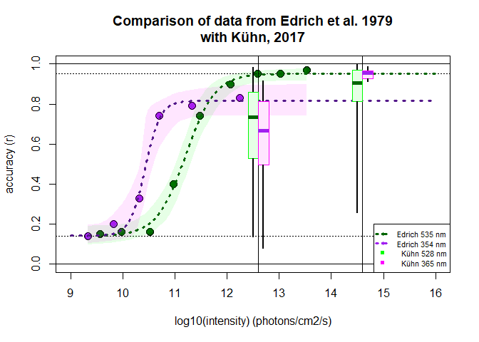

```r
#Prepare a sequence for plotting
xxl = seq(from = 9, to = 16,
          length.out = 1e3)

#plot only the stimulus types also used by Kühn.
ed_ug = subset(ed, wavelength != 429)

#plot each stimulus type
with(ed_ug,
     {
       plot(x = log10_intensity,
            y = accuracy,
            main =
'Comparison of data from Edrich et al. 1979
with Kühn, 2017',
            xlab = 'log10(intensity) (photons/cm2/s)',
            ylab = 'accuracy (r)',
            ylim = c(0,1),
            xlim = c(9,16),
            pch = 21,
            cex = 1.5,
            col = 'black',
            bg = sapply(paste(wavelength),
                        FUN = switch,
                        `354` = 'purple',
                        `429` = 'blue',
                        `535` = 'darkgreen',
                        'red')
       )
       abline(h = c(0,1))
       abline(v = log10(4*c(1e12,1e14)) )
     }
)
#Add the estimated range of the curve for the green stimulus
with(data.frame(t(full_estimates_beta)),
     {
  abline(h = c(0,1,
               plogis(LogitBase_Intercept),
               1- plogis(LogitLapse_Intercept) ),
         lty = c(1,1,3,3)
         )
     }
)

#plot total 95% prediction intervals
with(subset(pred_data_beta, colour == '0green'),
     {
       polygon(x = c(sort(log10_intensity), rev(sort(log10_intensity))),
               y = c(lower__[order(log10_intensity)],
                     rev(upper__[order(log10_intensity)])
               ),
               col = adjustcolor('green', alpha.f = 25/256),
               border = NA,
               lwd = 0.1
       )
     }
)
with(subset(pred_data_beta, colour == 'UV'),
     {
       polygon(x = c(sort(log10_intensity), rev(sort(log10_intensity))),
               y = c(lower__[order(log10_intensity)],
                     rev(upper__[order(log10_intensity)])
               ),
               col = adjustcolor('magenta', alpha.f = 25/256),
               border = NA,
               lwd = 0.1
       )
     }
)

#plot the median prediction lines
with(g_curve,
     lines(x = xxl,
           y = Base + (Maxima  - Base) *
             plogis(4.39*(xxl - Inflection)/Width),
           col = 'darkgreen',
           lwd = 3,
           lty = 3)
)
with(u_curve,
     lines(x = xxl,
           y = Base + (Maxima  - Base) *
             plogis(4.39*(xxl - Inflection)/Width),
           col = 'purple4',
           lwd = 3,
           lty = 3)
)

#plot observed data from Kühn as boxplots showing the quartiles, median and total range.
#Green High intensity
QBox(quant = subset(meanQ, colour %in% 'g' & brightn %in% 'h'),
     x = log10(4e14),
     offset = -0.1,
     cols = c('green', 'darkgreen')
    )

#Green Low intensity
QBox(quant = subset(meanQ, colour %in% 'g' & brightn %in% 'l'),
     x = log10(4e12),
     offset = -0.1,
     cols = c('green', 'darkgreen')
    )

#UV High intensity
QBox(quant = subset(meanQ, colour %in% 'u' & brightn %in% 'h'),
     x = log10(4e14),
     offset = 0.1,
     cols = c('magenta', 'purple')
    )

#UV Low intensity
QBox(quant = subset(meanQ, colour %in% 'u' & brightn %in% 'l'),
     x = log10(4e12),
     offset = 0.1,
     cols = c('magenta', 'purple')
    )

legend(x = 'bottomright',
       legend = c(
                   paste('Edrich',
                        sort(unique(ed_ug$wavelength),
                           decreasing = TRUE), 'nm'),
                   paste('  Kühn', c(528, 365), 'nm' )
       ),
       col = c('darkgreen', 'purple', 'green', 'magenta'),
       pch = c(20, 20, 15, 15),
       lty = c(3,3,NA, NA),
       lwd = 3,
       cex = 0.7)
```

It would be difficult to explain the orientation accuracy for the high intensity ($4*10^{14}$) UV stimulus from the accuracy curve for Edrich’s UV data, but it would fit well with the maximum accuracy observed for green light. In Edrich’s study, the green light was interpreted as the sun (dances at correct angle between sun and feeder), whereas the UV light was interpreted as a patch of sky near the anti-sun. In Kühn’s data the stimuli were larger (assuming $10°$ across) than Edrich’s ($2.3°$), which may have resulted in them being perceived as dimmer (left shift in this graph).

# Sun compass orientation

Since most dances were at least somewhat oriented ($r>0.5$) we can assume that the mean angles of these dances typically align with an intended dance direction. If most dances are for the same geographic location, we should observe dances as the same fixed angle to the stimulus, interpreted either as the sun or the anti-sun.

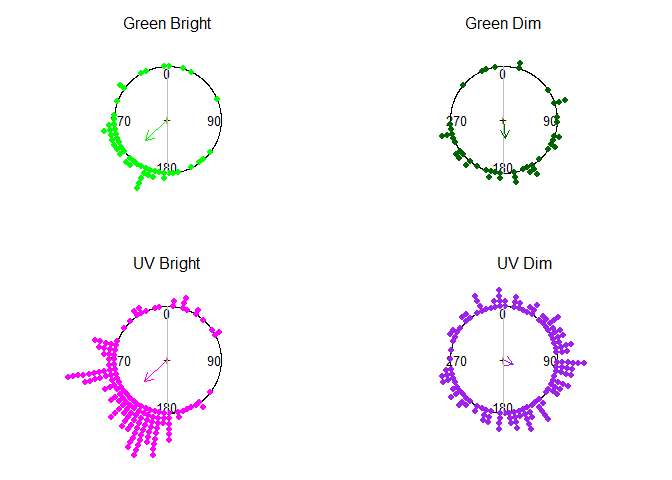

```r
sun_diff_gh = sapply(X = u_id,
                    FUN = SunDiff,
                    dt = mean_vectors,
                    cl = 'g',
                    br = 'h')
sun_diff_gl = sapply(X = u_id,
                    FUN = SunDiff,
                    dt = mean_vectors,
                    cl = 'g',
                    br = 'l')
sun_diff_uh = sapply(X = u_id,
                    FUN = SunDiff,
                    dt = mean_vectors,
                    cl = 'u',
                    br = 'h')
sun_diff_ul = sapply(X = u_id,
                    FUN = SunDiff,
                    dt = mean_vectors,
                    cl = 'u',
                    br = 'l')


par(mfrow = c(2,2), mar = c(0,0,0,0))
PCfun(angles = unlist(sun_diff_gh),
      col = 'green',
      shrink = 2.0,
      side = 3,
      title = 'Green Bright')
PCfun(angles = unlist(sun_diff_gl),
      col = 'darkgreen',
      shrink = 2.0,
      side = 3,
      title = 'Green Dim')
PCfun(angles = unlist(sun_diff_uh),
      col = 'magenta',
      shrink = 2.0,
      side = 3,
      title = 'UV Bright')
PCfun(angles = unlist(sun_diff_ul),
      col = 'purple',
      shrink = 2.0,
      side = 3,
      title = '           UV Dim')
```

For the bright stimuli the dances generally indicate South, but with a very wide range. (or possibly clusters to the South-West and South-East). For the dim stimuli there is less of a clear pattern, particularly for UV dim.

We can also restrict this analysis to just the dances with all conditions.

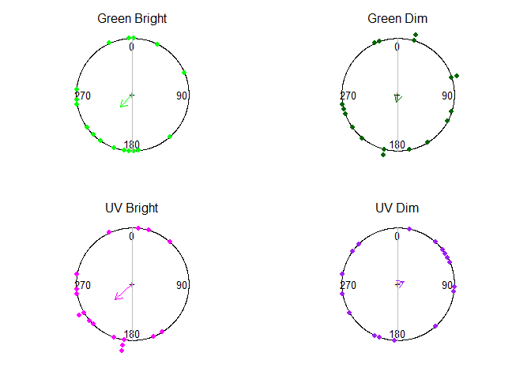

```r
full_sun_diff_gh = sapply(X = full_ids,
                    FUN = SunDiff,
                    dt = mean_vectors,
                    cl = 'g',
                    br = 'h')
full_sun_diff_gl = sapply(X = full_ids,
                    FUN = SunDiff,
                    dt = mean_vectors,
                    cl = 'g',
                    br = 'l')
full_sun_diff_uh = sapply(X = full_ids,
                    FUN = SunDiff,
                    dt = mean_vectors,
                    cl = 'u',
                    br = 'h')
full_sun_diff_ul = sapply(X = full_ids,
                    FUN = SunDiff,
                    dt = mean_vectors,
                    cl = 'u',
                    br = 'l')


par(mfrow = c(2,2), mar = c(0,0,0,0))
PCfun(angles = unlist(full_sun_diff_gh),
      col = 'green',
      shrink = 1.5,
      side = 3,
      title = 'Green Bright')
PCfun(angles = unlist(full_sun_diff_gl),
      col = 'darkgreen',
      shrink = 1.5,
      side = 3,
      title = 'Green Dim')
PCfun(angles = unlist(full_sun_diff_uh),
      col = 'magenta',
      shrink = 1.5,
      side = 3,
      title = 'UV Bright')
PCfun(angles = unlist(full_sun_diff_ul),
      col = 'purple',
      shrink = 1.5,
      side = 3,
      title = 'UV Dim')
```

# Inspect dance angles relative to the stimulus

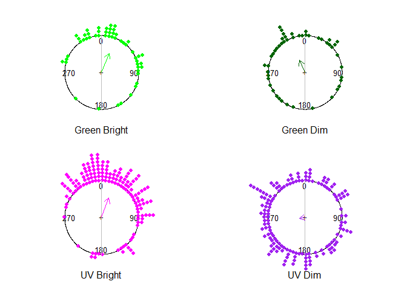

```r
par(mfrow = c(2,2), mar = c(0,0,0,0))
PCfun(angles = subset(mean_vectors,
                      subset = colour %in% 'g' & brightn %in% 'h')$mu,
      col = 'green',
      shrink = 1.75,
      title = 'Green Bright')
PCfun(angles = subset(mean_vectors,
                      subset = colour %in% 'g' & brightn %in% 'l')$mu,
      col = 'darkgreen',
      shrink = 1.75,
      title = 'Green Dim')
PCfun(angles = subset(mean_vectors,
                      subset = colour %in% 'u' & brightn %in% 'h')$mu,
      col = 'magenta',
      shrink = 1.75,
      title = 'UV Bright')
PCfun(angles = subset(mean_vectors,
                      subset = colour %in% 'u' & brightn %in% 'l')$mu,
      col = 'purple',
      shrink = 1.75,
      title = 'UV Dim')
```

```r
cd_sd = aggregate(circular(mu, units = 'degrees')~colour*brightn,
                  FUN = sd.circular,
                  data = mean_vectors)
cd_rho = aggregate(circular(mu, units = 'degrees')~colour*brightn,
                  FUN = rho.circular,
                  data = mean_vectors)
names(cd_sd)[3] = 'circular_sd'
names(cd_rho)[3] = 'rho'
cd_desc = merge(cd_sd, cd_rho)
cd_desc = within(cd_desc,
                 {sd_degrees = deg(circular_sd)})
print(cd_desc,digits = 2)
```

```
##   colour brightn circular_sd  rho sd_degrees
## 1      g       h         1.1 0.56         62
## 2      g       l         1.4 0.36         82
## 3      u       h         1.1 0.57         61
## 4      u       l         1.9 0.16        110
```

## Compare Sun-Spot & Phototaxis Hypotheses

```r
require(geosphere)#TODO move to functions
# Define the coordinates

hive_coords  =  c(longitude  = 8.811333,
                 latitude = 50.806306)
# garden_coords = c(longitude  = 8.806694,
#                   latitude = 50.800917) # flower beds
#centre according to google 50.802605, 8.809097
# left according to openstreetmap 50.802721, 8.806807



garden_coords = list(left =
                       c(longitude  = 8.806807,
                         latitude = 50.802721),
                     centre =
                       c(longitude  = 8.809097,
                         latitude = 50.802605),
                     right =
                       c(longitude  = 8.811926,
                         latitude = 50.803182)
                     )

garden_bearing = sapply(garden_coords,
                        FUN = bearing,
                        p1 = hive_coords
                        )
#standard bearing
print(garden_bearing %% 360)
```

```
##     left   centre    right
## 218.6614 200.9496 173.1410
```

```r
garden_bearing_rad = rad(as.numeric(garden_bearing[2]))
```

```r
#TODO save and load models instead of running them each time
load_model = TRUE
# Custom family --------------------------------------------------------
#In the "unwrap" family, all variables
unwrap_von_mises = custom_family(
  "unwrap_von_mises", dpars = c("mu", "kappa"),
  links = c('identity',#brms cannot accept custom link functions, do via nl instead
            "softplus"),
  lb = c(-pi, 0),
  ub = c(pi, NA),
  type = "real"
)

## Stan variables


### Functions

stan_unwrap_fun = stanvar(scode = "
  real unwrap_von_mises_lpdf(real y, real mu, real kappa) {
    return von_mises_lpdf(y | mod_circular(mu), kappa);
  }
  real unwrap_von_mises_rng(real mu, real kappa) {
    return von_mises_rng( mod_circular(mu) , kappa);
  }
  real unwrap_von_mises_vect_lpdf(vector y, real mu, real kappa) {
    real tmp = 0;
    for(i in 1:size(y))
    {
    tmp = tmp + unwrap_von_mises_lpdf(y[i] | mu, kappa);
    }
      return tmp;
  }
",
                          block = 'functions') +
  stanvar(scode = "
  real mod_circular(real y) {
    return fmod(y + pi(), 2*pi()) - pi();
  }

  real inv_mod_circular(real y) {
    return mod_circular(y);
  }
",
          block = 'functions')

### Parameters

#concentration of random effects on fixed effect on mean angle
kappamu_param = stanvar(scode = "
real kappamu;
                           ",
                            block = "parameters") +
  stanvar(scode = "
real kappa_mu = log1p_exp(kappamu);
          ",
          block = 'genquant')


stanvars_unwrap = stan_unwrap_fun + kappamu_param

#subset to just gh data
cd_gh = subset(cd,
               subset = brightn %in% 'h' &
                         colour %in% 'g' &
                         !is.na(sun_az_rad) # for fair comparison only include cases where the sun azimuth is known
               )

dt_photo = within(cd_gh,
            {
              BR = brightn
              CL = colour
              DT = date
              RN = run
              sunangle = angle + sun_az_rad
            }
)

#TODO oops I forgot this is a huge amount of data, I'll try the full set later

# dt_photo = subset(dt_photo,
#                   subset = ID %in% full_ids)

dt_sun = within(dt_photo,
                {bgangle = sunangle - garden_bearing_rad}
                )


# Model formulae
#model assuming mean direction at 0°, with individual biases
formula_photo = bf(
  formula = angle ~ mu,
            nlf(mu ~ fmu + zmu),
            fmu ~ 0, # fixed effects intercept == 0
            zmu ~ 0 + ID,
            kappa ~ 1 + (1|ID),
  family = unwrap_von_mises,#mod mu, kappa via the softplus
  nl = TRUE)#to accept user-defined extra parameters (zmu) we need to treat the formula as nonlinear

#model allowing any angle
formula_nophoto = bf(
  formula = angle ~ mu,
            nlf(mu ~ fmu + zmu),
            fmu ~ 1, # fixed effects intercept estimated
            zmu ~ 0 + ID,
            kappa ~ 1 + (1|ID),
  family = unwrap_von_mises,#mod mu, kappa via the softplus
  nl = TRUE)#to accept user-defined extra parameters (zmu) we need to treat the formula as nonlinear

formula_sunspot = bf(
  formula = bgangle ~ mu,
            nlf(mu ~ fmu + zmu),
            fmu ~ 0, # fixed effects intercept estimated
            zmu ~ 0 + ID,
            kappa ~ 1 + (1|ID),
  family = unwrap_von_mises,#mod mu, kappa via the softplus
  nl = TRUE)#to accept user-defined extra parameters (zmu) we need to treat the formula as nonlinear

formula_nosunspot = bf(
  formula = bgangle ~ mu,
            nlf(mu ~ fmu + zmu),
            fmu ~ 1, # fixed effects intercept estimated
            zmu ~ 0 + ID,
            kappa ~ 1 + (1|ID),
  family = unwrap_von_mises,#mod mu, kappa via the softplus
  nl = TRUE)#to accept user-defined extra parameters (zmu) we need to treat the formula as nonlinear

# Priors
#priors for mu
pr_photo =
  set_prior(paste("target +=",
                  'unwrap_von_mises_vect_lpdf(b_zmu | 0, log1p_exp(kappamu))',
                  '+ normal_lpdf(b_zmu | 0, 2*pi())'# additional prior to keep estimates from walking around the circle
  ),
  check = FALSE) +
  set_prior("target += normal_lpdf(kappamu | 1.0, 3.0)", #prior to lower values, indiv differences should be large
            check = FALSE) +
    prior(normal(3.0,3.0), class = Intercept, dpar = 'kappa') + # bias to oriented
  prior(student_t(3, 0, 3.0), class = sd, dpar = 'kappa')  # weak bias no differences

#for models with a mean we also need an extra parameter
pr_nophoto = pr_photo +
  prior(normal(0,2*pi()), class = b,  nlpar = 'fmu', coef = 'Intercept')

#parameters for the brms runs
wup = 1000
sam = 1000
refr = 0
siln = 0

#these are pretty slow! About 7 minutes in total
if(load_model)
{ load(file = '2Results/phototaxis_modlist.RData')
}else
  {
  cglm_photo = brm(formula = formula_photo,
                  data = dt_photo,
                  prior = pr_photo,
                  stanvars = stanvars_unwrap,
                  warmup = wup,#may be necessary
                  iter = wup+sam, #doesn't take a lot of runs
                  chains = 4, # 4 chains in parallel
                  cores = 4, # on 4 CPUs
                  # control = list(adapt_delta = 0.90),
                 refresh = refr, # echo chain progress every n iterations
                 silent = siln, # echo some Stan messages
                  save_pars = save_pars(all = TRUE), # <--- Crucial for moment matching
                 backend = 'cmdstanr')

  cglm_nophoto = brm(formula = formula_nophoto,
                  data = dt_photo,
                  prior = pr_nophoto,
                  stanvars = stanvars_unwrap,
                  warmup = wup,#may be necessary
                  iter = wup+sam, #doesn't take a lot of runs
                  chains = 4, # 4 chains in parallel
                  cores = 4, # on 4 CPUs
                  # control = list(adapt_delta = 0.90),
                 refresh = refr, # echo chain progress every n iterations
                 silent = siln, # echo some Stan messages
                  save_pars = save_pars(all = TRUE), # <--- Crucial for moment matching
                 backend = 'cmdstanr')

  cglm_sunspot = brm(formula = formula_sunspot,
                  data = dt_sun,
                  prior = pr_photo,#different response, same predictors
                  stanvars = stanvars_unwrap,
                  warmup = wup,#may be necessary
                  iter = wup+sam, #doesn't take a lot of runs
                  chains = 4, # 4 chains in parallel
                  cores = 4, # on 4 CPUs
                  # control = list(adapt_delta = 0.90),
                 refresh = refr, # echo chain progress every n iterations
                 silent = siln, # echo some Stan messages
                  save_pars = save_pars(all = TRUE), # <--- Crucial for moment matching
                 backend = 'cmdstanr')

  cglm_nosunspot = brm(formula = formula_nosunspot,
                  data = dt_sun,
                  prior = pr_nophoto,#different response, same predictors
                  stanvars = stanvars_unwrap,
                  warmup = wup,#may be necessary
                  iter = wup+sam, #doesn't take a lot of runs
                  chains = 4, # 4 chains in parallel
                  cores = 4, # on 4 CPUs
                  control = list(adapt_delta = 0.90),
                 refresh = refr, # echo chain progress every n iterations
                 silent = siln, # echo some Stan messages
                  save_pars = save_pars(all = TRUE), # <--- Crucial for moment matching
                 backend = 'cmdstanr')
#combine into a single list
modlist = list(phototaxis = cglm_photo,
            no_phototaxis = cglm_nophoto,
            sunspot = cglm_sunspot,
            no_sunspot = cglm_nosunspot)
  }
#summarise
suppressWarnings({ #for circular models rhats may be smaller than they appear
sm_modlist = lapply(X = modlist,
       FUN = summary)
})
Sm_only = function(x,
                   type = 'fixed',
                   var = 'kappa_Intercept')
{
  x[[type]][var,]
}

#average kappa
print(lapply(X = sm_modlist, Sm_only), digits = 3 )
```

```
## $phototaxis
##                 Estimate Est.Error l-95% CI u-95% CI Rhat Bulk_ESS Tail_ESS
## kappa_Intercept     8.67      1.04     6.74     10.9    1     1607     2053
##
## $no_phototaxis
##                 Estimate Est.Error l-95% CI u-95% CI Rhat Bulk_ESS Tail_ESS
## kappa_Intercept      8.7     0.996     6.84     10.7 1.01      983     1833
##
## $sunspot
##                 Estimate Est.Error l-95% CI u-95% CI Rhat Bulk_ESS Tail_ESS
## kappa_Intercept      8.6     0.997     6.67     10.6    1     1435     2089
##
## $no_sunspot
##                 Estimate Est.Error l-95% CI u-95% CI Rhat Bulk_ESS Tail_ESS
## kappa_Intercept     8.64         1     6.77     10.7 1.01     1133     1629
```

```r
#across individuals kappa
print(lapply(X = sm_modlist, Sm_only, type = 'spec_pars', var = 'kappa_mu'), digits = 3 )
```

```
## $phototaxis
##          Estimate Est.Error l-95% CI u-95% CI Rhat Bulk_ESS Tail_ESS
## kappa_mu     1.39     0.285    0.861     1.97    1     5818     2819
##
## $no_phototaxis
##          Estimate Est.Error l-95% CI u-95% CI Rhat Bulk_ESS Tail_ESS
## kappa_mu      1.5     0.303    0.944     2.12    1     2933     2631
##
## $sunspot
##          Estimate Est.Error l-95% CI u-95% CI Rhat Bulk_ESS Tail_ESS
## kappa_mu     1.17     0.254    0.683     1.71    1     5562     2939
##
## $no_sunspot
##          Estimate Est.Error l-95% CI u-95% CI Rhat Bulk_ESS Tail_ESS
## kappa_mu     1.18     0.275    0.672     1.75    1     4097     2611
```

```r
#TODO add to functions
SumUwRhats = function(x, var = NULL){summary(UnwrapRhats(x, variable = var))}
#check population means
lapply(X = modlist[c(2,4)],
       FUN = UnwrapRhats,
       variable = '^b_fmu')
```

```
## $no_phototaxis
## b_fmu_Intercept
##          1.0435
##
## $no_sunspot
## b_fmu_Intercept
##         1.00124
```

```r
#TODO check what is wrong with nosunspot
lapply(X = modlist,
       FUN = SumUwRhats)
```

```
## $phototaxis
##    Min. 1st Qu.  Median    Mean 3rd Qu.    Max.
##  0.9998  1.0000  1.0002  1.0004  1.0006  1.0051
##
## $no_phototaxis
##    Min. 1st Qu.  Median    Mean 3rd Qu.    Max.
##  0.9998  1.0000  1.0008  1.0078  1.0129  1.0435
##
## $sunspot
##    Min. 1st Qu.  Median    Mean 3rd Qu.    Max.
##  0.9998  0.9999  1.0002  1.0005  1.0007  1.0042
##
## $no_sunspot
##    Min. 1st Qu.  Median    Mean 3rd Qu.    Max.
##  0.9998  1.0000  1.0003  1.0004  1.0007  1.0030
```

```r
#calculate loo
if(!load_model)
{
modlist = lapply(modlist,
       FUN = add_criterion,
       'loo',
       moment_match = TRUE)

save(modlist,
     file = '2Results/phototaxis_modlist.RData')
}
#compare the phototaxis models
with(modlist, loo_compare(phototaxis, no_phototaxis))
```

```
##               elpd_diff se_diff
## no_phototaxis  0.0       0.0
## phototaxis    -0.9       0.8
```

```r
#compare the sun-spot orientation models
with(modlist, loo_compare(sunspot, no_sunspot))
```

```
##            elpd_diff se_diff
## no_sunspot  0.0       0.0
## sunspot    -0.8       0.6
```

```r
#compare LOO IC
LooIC = function(lmod)
{
  loo(lmod)$estimates['looic', 'Estimate']
}

modLIC = lapply(X = modlist,
       FUN = LooIC)
print(sort(unlist(modLIC)), digits = 1)
```

```
##    no_sunspot       sunspot no_phototaxis    phototaxis
##           636           638           638           640
```

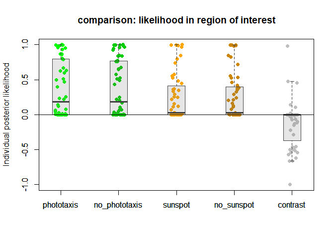

```r
#since all models are similarly credible, what about the hypotheses?
#check if the sector surrounding the expected direction is equally full

# bayestestR::rope(x = modlist$no_phototaxis,
#                  range = c(-1,1)*pi/4,
#                  parameters = 'fixed_fmu',
#                  effects = 'all',
#                  verbose = FALSE)
# bayestestR::rope(x = modlist$no_sunspot,
#                  range = c(-1,1)*pi/4,
#                  parameters = 'fmu_Intercept',
#                  effects = 'all',
#                  verbose = FALSE)
dr_modlist = lapply(modlist,
                    as_draws_df)
#for each individual, calculate the likelihood of foraging in the expected region

PostROPE = function(id, rope, drs, mu = 'b_fmu_Intercept')
{
  mu = if(!is.na(mu)){with(drs, get(mu))}else{0}
  dr_id = with(drs,
               {
               mod_circular(
                 mu +
                  get(paste0('b_zmu_ID', id)
                            )
               )
               }
              )
  #centre both
  circ_rope = circular(rope, template = 'none')
  circ_dr = circular(dr_id, template = 'none')
  mean_rope = mean.circular(circ_rope)
  rope_ctr = as.numeric(mod_circular(circ_rope - mean_rope))
  dr_ctr = as.numeric(mod_circular(dr_id - mean_rope))
  postp = mean( rope_ctr[1] < dr_id &
                dr_id  < rope_ctr[2])
  return(postp)
}

photo_id = unique(dt_photo$ID)

#width of sector
rope_width = abs(mod_circular(rad(diff(garden_bearing[-2])))) # 35°
rope_photo = c(-1,1)*rope_width/2
rope_sunspot = sort( mod_circular(rad(garden_bearing[-2] - garden_bearing[2])) )

postl_nophoto  = sapply(X = photo_id,
       FUN = PostROPE,
       rope = rope_photo,
       drs = dr_modlist$no_phototaxis
       )
postl_photo  = sapply(X = photo_id,
       FUN = PostROPE,
       rope = rope_photo,
       mu = NA,
       drs = dr_modlist$phototaxis
       )

postl_nosunspot  = sapply(X = photo_id,
       FUN = PostROPE,
       rope = rope_sunspot, # relative to centre as in model
       drs = dr_modlist$no_sunspot
       )
postl_sunspot  = sapply(X = photo_id,
       FUN = PostROPE,
       rope = rope_sunspot, # relative to centre as in model
       drs = dr_modlist$sunspot,
       mu = NA
       )

postl_dt = data.frame(phototaxis = postl_photo,
                      no_phototaxis = postl_nophoto,
                     sunspot = postl_sunspot,
                     no_sunspot = postl_nosunspot,
                     contrast = postl_sunspot -
                                 postl_photo)

stripchart(x = postl_dt,
           vertical = TRUE,
           method = 'jitter',
           pch = 19,
           ylab = 'Individual posterior likelihood',
           main = 'comparison: likelihood in region of interest',
           col = c('green','green3', 'orange','orange3', 'gray')
           )
boxplot(x = postl_dt,
        add = TRUE,
        col = gray(0.5, alpha = 0.2),
        border = 'gray25',
         pars = list(boxwex = 0.3, staplewex = 0.2, outwex = 0.1),
        outline = FALSE
         )
abline(h = 0)
```

It is hard to say for the individuals whether the majority orient towards the sector containing the Botanic Garden, or a similar sized sector containing the stimulus. What we can say is that the population average falls directly towards the Botanic Garden centre in real-world bearings, while the population average relative to the light source has a leftwards bias.

```r
with(dr_modlist$no_phototaxis, paste0(mean(b_fmu_Intercept > 0)*100, '%') ) #nearly all estimates suggest a leftwards bias
```

```
## [1] "1.05%"
```

```r
with(dr_modlist$no_sunspot, paste0(mean(b_fmu_Intercept > 0)*100, '%') ) #there is notable overlap between the high-density posterior and centre of Botanic Gardens.
```

```
## [1] "13.175%"
```

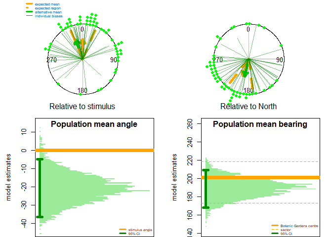

```r
par(pty = 's')
par(mfrow = c(2,2),
    mar = c(0,0,0,0))
PCfun(angles = subset(mean_vectors,
                      subset = colour %in% 'g' &
                                brightn %in% 'h' &
                                !is.na(sun_az))$mu,
      col = 'green',
      shrink = 1.5,
      plot_rho = FALSE,
      title = '\nRelative to stimulus')
with(dr_modlist$phototaxis,
     arrows(x0 = 0, x1 = 0,
            y0 = 0,
            y1 = #A1(softplus(median(b_kappa_Intercept)))
              A1(softplus(median(kappamu))),
            col = 'orange',
            lwd = 5,
            length = 0.1
            )
)
# Draws2Cont(dr_modlist$no_phototaxis,
#            x_string = paste0('sin(',
#                              'b_fmu_Intercept',
#                              ')*',
#                              'A1(softplus(',
#                              'b_kappa_Intercept',
#                              '))'),
#            y_string = paste0('cos(',
#                              'b_fmu_Intercept',
#                              ')*',
#                              'A1(softplus(',
#                              'b_kappa_Intercept',
#                              '))'),
#            palette = 'Grays'
# )




with(dr_modlist$no_phototaxis,
     arrows(x0 = 0,
            x1 = #A1(softplus(median(b_kappa_Intercept)))*
              A1(softplus(median(kappamu)))*
              sin(median(mod_circular(b_fmu_Intercept))),
            y0 = 0,
            y1 = #A1(softplus(median(b_kappa_Intercept)))*
              A1(softplus(median(kappamu)))*
              cos(median(mod_circular(b_fmu_Intercept))),
            col = 'green3',
            lwd = 5,
            length = 0.1
            )
)
arrows(x0 = c(0,0),
       x1 = sin(c(-1,1)*rope_width/2),
       y0 = c(0,0),
       y1 = cos(c(-1,1)*rope_width/2),
       col = 'orange',
       lty = 2,
       length = 0,
       lwd = 5
       )
for(id in unique(dt_photo$ID))
{
  with(dr_modlist$no_phototaxis,
       arrows(x0 = 0,
              x1 = A1(softplus(median(
                    b_kappa_Intercept +
                    get(paste0('r_ID__kappa[',id,',Intercept]'))
                                              )))*
                sin(median(mod_circular(
                  b_fmu_Intercept +
                                          get(paste0('b_zmu_ID', id))
                                        ))),
              y0 = 0,
              y1 = A1(softplus(median(
                    b_kappa_Intercept +
                    get(paste0('r_ID__kappa[',id,',Intercept]')))))*
                cos(median(mod_circular(
                  b_fmu_Intercept +
                                          get(paste0('b_zmu_ID', id))
                                        ))),
              col = adjustcolor('green4',alpha = 0.5),
              lwd = 0.5,
              length = 0
              )
  )
}
legend(x = 'topleft',
       legend = c('expected mean',
                  'expected region',
                  'alternative mean',
                  'individual biases'
                  ),
       col = c('orange',
               'orange',
               'green3',
               'green4'
               ),
       lty = c(1,3,1,1),
       lwd = c(3,3,3,1),
       cex = 0.5,
       bg = NA,
       bty = 'n',
       inset = c(0, 0)
       )





PCfun(angles = with(subset(mean_vectors,
                      subset = colour %in% 'g' &
                                brightn %in% 'h' &
                                !is.na(sun_az)),
                    mu + sun_az),
      col = 'green',
      shrink = 1.5,
      plot_rho = FALSE,
      title = '\nRelative to North')
with(as_draws_df(modlist$sunspot),
     arrows(x0 = 0,
            x1 = #A1(softplus(median(b_kappa_Intercept)))*
              A1(softplus(median(kappamu)))*
              sin(garden_bearing_rad),
            y0 = 0,
            y1 = #A1(softplus(median(b_kappa_Intercept)))*
              A1(softplus(median(kappamu)))*
              cos(garden_bearing_rad),
            col = 'orange',
            lwd = 5,
            length = 0.1
            )
)
with(as_draws_df(modlist$no_sunspot),
     arrows(x0 = 0,
            x1 = #A1(softplus(median(b_kappa_Intercept)))*
              A1(softplus(median(kappamu)))*
              sin(median(mod_circular(b_fmu_Intercept+garden_bearing_rad                                         ))),
            y0 = 0,
            y1 = #A1(softplus(median(b_kappa_Intercept)))*
              A1(softplus(median(kappamu)))*
              cos(median(mod_circular(b_fmu_Intercept+garden_bearing_rad
                                        ))),
            col = 'green3',
            lwd = 5,
            length = 0.1
            )
)
arrows(x0 = c(0,0),
       x1 = sin(rad(garden_bearing[-2])),
       y0 = c(0,0),
       y1 = cos(rad(garden_bearing[-2])),
       col = 'orange',
       lty = 2,
       length = 0,
       lwd = 5
       )
for(id in unique(dt_photo$ID))
with(as_draws_df(modlist$no_sunspot),
     arrows(x0 = 0,
            x1 = A1(softplus(median(
                    b_kappa_Intercept +
                    get(paste0('r_ID__kappa[',id,',Intercept]')))))*
              sin(median(mod_circular(
                b_fmu_Intercept+
                garden_bearing_rad +
                                          get(paste0('b_zmu_ID', id))
                                        ))),
            y0 = 0,
            y1 = A1(softplus(median(
                    b_kappa_Intercept +
                    get(paste0('r_ID__kappa[',id,',Intercept]')))))*
              cos(median(mod_circular(
                b_fmu_Intercept+
                  garden_bearing_rad +
                                          get(paste0('b_zmu_ID', id))
                                        ))),
            col = adjustcolor('green4',alpha = 0.5),
            lwd = 0.5,
            length = 0
            )
)
# Draws2Cont(dr_modlist$no_sunspot,
#            alpha = 100/255,
#            x_string = paste0('sin(',
#                              'b_fmu_Intercept+garden_bearing_rad',
#                              ')*',
#                              'A1(softplus(',
#                              'b_kappa_Intercept',
#                              '))'),
#            y_string = paste0('cos(',
#                              'b_fmu_Intercept+garden_bearing_rad',
#                              ')*',
#                              'A1(softplus(',
#                              'b_kappa_Intercept',
#                              '))'),
#            palette = 'Grays'
# )

par(mar = c(0,3,0,0))

with(dr_modlist$no_phototaxis,
     {
      VertHist(data = deg(b_fmu_Intercept),
         main = '\nPopulation mean angle',
         ylab = 'model estimates',
         ylim = c(-45, 15),
         col = adjustcolor('green3', alpha.f = 100/255),
         cex.axis = 0.7)
       abline(h = 0,
       col = 'orange',
       lwd = 7)
       arrows(x0 = 0, x1 = 0,
              y0 = quantile(deg(b_fmu_Intercept), p = 0.025),
              y1 = quantile(deg(b_fmu_Intercept), p = 1-0.025),
              col = 'green4',
              lwd = 5,
              code = 3,
              length = 0.05,
              angle = 90)
     }
       )

legend(x = 'bottomright',
       legend = c('stimulus angle',
                  '95% CI'
                  ),
       col = c('orange',
               'green4'
               ),
       lty = c(1,1),
       lwd = c(3,3),
       cex = 0.5,
       bg = NA,
       bty = 'n',
       inset = c(0, 0)
       )



gb_pos = garden_bearing[2] %% 360

with(dr_modlist$no_sunspot,
     {
      VertHist(data = deg(b_fmu_Intercept)  + gb_pos,
               main = '\nPopulation mean bearing',
               ylab = 'model estimates',
               ylim = c(-60, 60) + gb_pos,
               col = adjustcolor('green3', alpha.f = 100/255),
               cex.axis = 0.7)
      abline(h = garden_bearing %% 360,
             col = 'orange',
             lwd = c(1,7,1),
             lty = c(2,1,2) )
       arrows(x0 = 0, x1 = 0,
              y0 = quantile(deg(b_fmu_Intercept), p = 0.025) +
                gb_pos,
              y1 = quantile(deg(b_fmu_Intercept), p = 1-0.025) +
                gb_pos,
              col = 'green4',
              lwd = 5,
              code = 3,
              length = 0.05,
              angle = 90)
     }
       )

legend(x = 'bottomright',
       legend = c('Botanic Gardens centre',
                  'sector',
                  '95% CI'
                  ),
       col = c('orange',
               'orange',
               'green4'
               ),
       lty = c(1,2,1),
       lwd = c(3,0.5,3),
       cex = 0.5,
       bg = NA,
       bty = 'n',
       inset = c(0, 0)
       )
```

```r
#How much to individual dance angles vary according to kappa_mu?
with(sm_modlist$no_sunspot,
     paste0(round(deg(MardiaSD(spec_pars['kappa_mu' ,'Estimate']))), '°') )
```

```
## [1] "67°"
```

```r
#Where is the population centred?
with(dr_modlist$no_sunspot,
     {
     paste0(
       round(
       quantile(x = deg(b_fmu_Intercept),
                p = c(0,0.5,1)+c(1,0,-1)*(0.05/2) ) +
                gb_pos
                ) %% 360, # as a bearing
       '°' )
     }
)
```

```
## [1] "168°" "190°" "210°"
```

## Mean dance angles relative to the stimulus (full conditions)

Since dances do not point to a specific geographic location, it is possible that they advertise a variety of directions relative to the sun, or are not menotactic but phototactic or uniformly oriented. We can identify phototactic orientation from the angle relative to the stimulus.

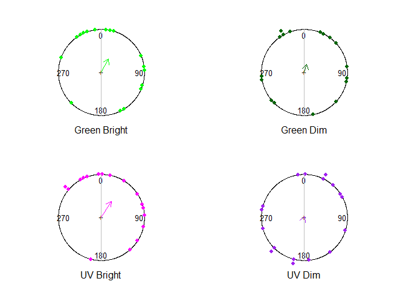

```r
par(mfrow = c(2,2), mar = c(0,0,0,0))
PCfun(angles = subset(mean_vectors_full,
                      subset = colour %in% 'g' & brightn %in% 'h')$mu,
      col = 'green',
      shrink = 1.5,
      title = 'Green Bright')
PCfun(angles = subset(mean_vectors_full,
                      subset = colour %in% 'g' & brightn %in% 'l')$mu,
      col = 'darkgreen',
      shrink = 1.5,
      title = 'Green Dim')
PCfun(angles = subset(mean_vectors_full,
                      subset = colour %in% 'u' & brightn %in% 'h')$mu,
      col = 'magenta',
      shrink = 1.5,
      title = 'UV Bright')
PCfun(angles = subset(mean_vectors_full,
                      subset = colour %in% 'u' & brightn %in% 'l')$mu,
      col = 'purple',
      shrink = 1.5,
      title = 'UV Dim')
```

While there are some dances towards or near to the stimulus for most conditions, there is a wide spread, suggesting a factor other than phototaxis sets dance directions. N.B. for the dim stimuli where the widest spread is observed, the dances are also less accurate, which may increase variation in mean dance angle.

```r
cd_sd_full = aggregate(circular(mu, units = 'degrees')~colour*brightn,
                  FUN = sd.circular,
                  data = mean_vectors_full)
cd_rho_full = aggregate(circular(mu, units = 'degrees')~colour*brightn,
                  FUN = rho.circular,
                  data = mean_vectors_full)
names(cd_sd_full)[3] = 'circular_sd'
names(cd_rho_full)[3] = 'rho'
cd_desc_full = merge(cd_sd_full, cd_rho_full)
cd_desc_full = within(cd_desc_full,
                 {sd_degrees = deg(circular_sd)})
print(cd_desc_full,digits = 2)
```

```
##   colour brightn circular_sd   rho sd_degrees
## 1      g       h         1.4 0.351         83
## 2      g       l         1.8 0.200        103
## 3      u       h         1.3 0.438         74
## 4      u       l         2.9 0.016        164
```

## Change in mean dance angle between stimuli

### Change arcs

To determine whether these dances interpret the stimuli as the sun, anti-sun or something else, we would need to check the differences in dance angle between the conditions. It is also worth considering any differences in accuracy between dances to each condition, since this would influence the variation in angular change. These can be visualised as arcs.

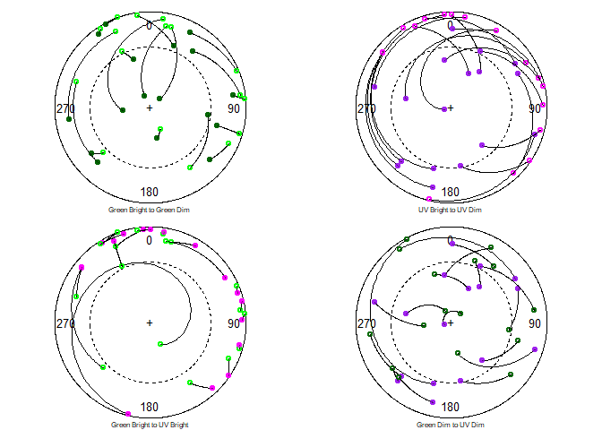

```r
#TODO make a function for this
par(mfrow = c(2,2), mar = c(0,0,0,0))
OpenCplot(n_sample = with(full_cd, median(run)/4) )
mtext(text = 'Green Bright to Green Dim',
      side = 1,
      line = -1,
      cex = 0.5)
#open the loop
for(ii in mean_vectors_full$ID)
{
with(subset(mean_vectors_full,
            subset = ID %in% ii),
     {
      DiffArc(a1 = mu[colour %in% 'g' &
                      brightn %in% 'h'],
              a2 = mu[colour %in% 'g' &
                        brightn %in% 'l'],
              r1 = mean_vector[colour %in% 'g' &
                              brightn %in% 'h'],
              r2 = mean_vector[colour %in% 'g' &
                                brightn %in% 'l'],
              col1 = 'green',
              col2 = 'darkgreen'
              )
     }
    )
}

OpenCplot(n_sample = with(full_cd, median(run)/4) )
mtext(text = 'UV Bright to UV Dim',
      side = 1,
      line = -1,
      cex = 0.5)
for(ii in mean_vectors_full$ID)
{
with(subset(mean_vectors_full,
            subset = ID %in% ii),
     {
      DiffArc(a1 = mu[colour %in% 'u' &
                      brightn %in% 'h'],
              a2 = mu[colour %in% 'u' &
                        brightn %in% 'l'],
              r1 = mean_vector[colour %in% 'u' &
                              brightn %in% 'h'],
              r2 = mean_vector[colour %in% 'u' &
                                brightn %in% 'l'],
              col1 = 'magenta',
              col2 = 'purple'
              )
     }
    )
}
OpenCplot(n_sample = with(full_cd, median(run)/4) )
mtext(text = 'Green Bright to UV Bright',
      side = 1,
      line = -1,
      cex = 0.5)
for(ii in mean_vectors_full$ID)
{
with(subset(mean_vectors_full,
            subset = ID %in% ii),
     {
      DiffArc(a1 = mu[colour %in% 'g' &
                      brightn %in% 'h'],
              a2 = mu[colour %in% 'u' &
                        brightn %in% 'h'],
              r1 = mean_vector[colour %in% 'g' &
                              brightn %in% 'h'],
              r2 = mean_vector[colour %in% 'u' &
                                brightn %in% 'h'],
              col1 = 'green',
              col2 = 'magenta'
              )
     }
    )
}
OpenCplot(n_sample = with(full_cd, median(run)/4) )
for(ii in mean_vectors_full$ID)
{
with(subset(mean_vectors_full,
            subset = ID %in% ii),
     {
      DiffArc(a1 = mu[colour %in% 'g' &
                      brightn %in% 'l'],
              a2 = mu[colour %in% 'u' &
                        brightn %in% 'l'],
              r1 = mean_vector[colour %in% 'g' &
                              brightn %in% 'l'],
              r2 = mean_vector[colour %in% 'u' &
                                brightn %in% 'l'],
              col1 = 'darkgreen',
              col2 = 'purple'
              )
     }
    )
}
mtext(text = 'Green Dim to UV Dim',
      side = 1,
      line = -1,
      cex = 0.5)
```

### Differences in mean angle

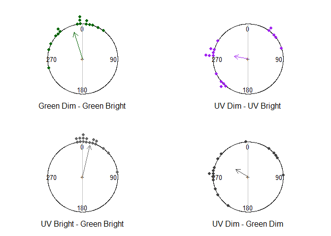

```r
mu_diff_gl = sapply(X = full_ids,
                    FUN = MuDiff,
                    dt = mean_vectors_full,
                    cl = 'g',
                    br = 'l')
mu_diff_uh = sapply(X = full_ids,
                    FUN = MuDiff,
                    dt = mean_vectors_full,
                    cl = 'u',
                    br = 'h')
mu_diff_ul = sapply(X = full_ids,
                    FUN = MuDiff,
                    dt = mean_vectors_full,
                    cl = 'u',
                    br = 'l')


#Other contrasts
mu_diff_uhl = sapply(X = full_ids,
                    FUN = MuDiff,
                    dt = mean_vectors_full,
                    cl = 'u',
                    br = 'l',
                    ref_cl = 'u',
                    ref_br = 'h')
mu_diff_gul = sapply(X = full_ids,
                    FUN = MuDiff,
                    dt = mean_vectors_full,
                    cl = 'u',
                    br = 'l',
                    ref_cl = 'g',
                    ref_br = 'h')

par(mfrow = c(2,2), mar = c(0,0,0,0))
PCfun(angles = unlist(mu_diff_gl),
      col = 'darkgreen',
      shrink = 1.5,
      title = 'Green Dim - Green Bright')
PCfun(angles = unlist(mu_diff_uhl),
      col = 'purple',
      shrink = 1.5,
      title = 'UV Dim - UV Bright')
PCfun(angles = unlist(mu_diff_uh),
      col = 'gray40',
      shrink = 1.5,
      title = 'UV Bright - Green Bright')
PCfun(angles = unlist(mu_diff_gul),
      col = 'gray25',
      shrink = 1.5,
      title = 'UV Dim - Green Dim')
```

# Estimate turn effects

## Find fit maximum likelihood turn distributions

For each change distribution, find the maximum likelihood von Mises distribution. For the UV high to UV low change, this will be a bimodal distribution.

```r
#collect all heading differences
pair_diffs_lst = lapply(X = list(#bright vs dim green
                                green_hl = mu_diff_gl,
                                #bright vs dim UV
                                uv_hl = mu_diff_uhl,
                                #bright green vs bright uv
                                uvg_h = mu_diff_uh,
                                #dim green vs bright UV
                                 uvg_l = mu_diff_gul ),
                        FUN = unlist)
#Provide appropriate data format
angle_unit = 'degrees'
angle_rot = 'clock'
#make sure they are in circular format
pair_diffs_lst = lapply(X = pair_diffs_lst,
                        FUN = circular,
                        units = angle_unit,
                        rotation = angle_rot)
```

Fit the maximum likelihood distribution for no difference between pairs, differences between pairs, and differences between pairs with two means. If angles shift in one direction between trials, the “difference” distribution should have significantly higher likelihood. If angles shift in two directions between pairs, then the “two means” distribution should be the best fit.

```r
#TODO neaten up!
#Distribution for same means
ml_same_lst = lapply(X = pair_diffs_lst,
                     mle.vonmises,
                     bias = TRUE,
                     mu = circular(x = 0,
                                   units = angle_unit,
                                   rotation = angle_rot)
)
#Distribution for different means
ml_diff_lst = lapply(X = pair_diffs_lst,
                     mle.vonmises,
                     bias = TRUE)
#Distribution for multiple different means
mod_diff_lst = lapply(X = pair_diffs_lst,
                      FUN = circ_mle,#converts circular format data to radians
                      niter = 1e4)#some stochastic variability for green stim
#Forced multiple different means
bim_diff_lst = lapply(X = pair_diffs_lst,
                      FUN = circ_mle,#converts circular format data to radians
                      exclude = c('M1','M2A', 'M2B', 'M2C'),#no uniform or unimodal
                      niter = 1e4)#some stochastic variability for green stim
```

```r
#Extract the parameters of the model with the lowest AIC
mod_diff_par = t( sapply(X = mod_diff_lst,
                      FUN = MD_extract) )
bim_diff_par = t( sapply(X = bim_diff_lst,
                      FUN = MD_extract) )

# Calculate likelihood
#calculate all in list
all_ll = mapply(FUN = LLcalc,
                ml = c(ml_same_lst, ml_diff_lst), #apply to both sets of ML estimates
                angles = pair_diffs_lst, #repeat datasets
                au = angle_unit, #important, use the same frame of reference as the original
                ar = angle_rot)

#inspect resulting parameters
mod_diff_results = do.call(rbind, c(ml_same_lst, ml_diff_lst))
#add easy to parse names
rownames(mod_diff_results) = paste( sort( #distinguish same and different mean
                          rep(x = c( 'same', 'diff'),
                              times =  length(pair_diffs_lst) ),
                          decreasing = TRUE
                          ),
                       rep(x = names(pair_diffs_lst),
                           times = 2)
                       )
#display version
rspar = mod_diff_results[,c('mu', 'kappa', 'se.mu', 'se.kappa')]
rspar = cbind(rspar, loglikelihood = all_ll)
rspar = apply(X = rspar, MARGIN = 2, FUN = unlist)
#reorder for easy comparison
rspar = rspar[c(rbind(1:4, 1:4+4)),]#put the different directly after the same
rspar[,3:4] = NA
rspar = cbind(rspar, weight1 = 1.0)
colnames(rspar) = colnames(bim_diff_par)[c(1:4, 6:5)]
all_res = rbind(data.frame(rspar),
                data.frame(bim_diff_par) )
all_res = apply(all_res, MARGIN = 2, FUN = unlist)
rn_res = rownames(all_res)#NB in R4.5 need to make a copy of rownames
rn_res[9:12] = paste('multi', rownames(bim_diff_par))
rownames(all_res) = rn_res #
#rownames(all_res[9:12,]) = paste('multi', rownames(bim_diff_par))
all_res = all_res[c(1:2, 9, 3:4, 10, 5:6, 11, 7:8, 12),]

all_res = within(data = data.frame(all_res),
                 {
                   model = c('same',
                             'diff',
                             'multi')
                   dataset = c(sapply(X = names(pair_diffs_lst),
                                    FUN = rep,
                                    times = 3) )
                 }
                )
# print(rspar, digits = 3)
# print(mod_diff_par, digits = 3)
# print(bim_diff_par, digits = 3)
print(all_res, digits = 3)
```

```
##                  mu1 kappa1   mu2 kappa2 loglikelihood weight1  dataset model
## same green_hl    0.0  2.046    NA     NA         -19.3   1.000 green_hl  same
## diff green_hl  -17.5  2.361    NA     NA         -17.7   1.000 green_hl  diff
## multi green_hl 289.9  5.696   0.0   5.70         -16.2   0.346 green_hl multi
## same uv_hl       0.0  0.000    NA     NA         -31.2   1.000    uv_hl  same
## diff uv_hl     -78.8  0.763    NA     NA         -28.3   1.000    uv_hl  diff
## multi uv_hl     49.3 20.938 260.1   4.80         -18.2   0.294    uv_hl multi
## same uvg_h       0.0  4.464    NA     NA         -10.9   1.000    uvg_h  same
## diff uvg_h      13.1  5.827    NA     NA          -8.4   1.000    uvg_h  diff
## multi uvg_h    357.6  5.018  42.9   5.02         -10.3   0.750    uvg_h multi
## same uvg_l       0.0  0.184    NA     NA         -30.7   1.000    uvg_l  same
## diff uvg_l     -58.4  0.786    NA     NA         -28.2   1.000    uvg_l  diff
## multi uvg_l     47.3  4.979 270.7   4.98         -22.1   0.347    uvg_l multi
```

```r
#save results
write.table(x = all_res,
          file = '2Results/MLE_paired_diffs.csv',
          sep = ',',
          row.names = TRUE)
```